# FIA - NLS Models: Biomass vs. Stand Age, G-Reconciled, Temporally-balanced, No harvest

JAH

2022-10-25

# Background

This document has nls (non-linear least squares) regression fits using the Michaelis-Menten functional form to USFS FIA (United States Forest Service Forest Inventory & Analysis) **biomass vs. stand age** relationships. We calculated the biomass of each FIA plot by summing alive tree biomass (as reported by FIA). Stand age is also reported by FIA, using tree-core age estimates from two trees from the dominant size class of the FIA plot.

We considered the following Michaelis-Menten functional form $B = (1 + (yr-1990)* ge/100) \times (1 - \alpha \cdot B_l) \times (1 + \phi \cdot \Delta PDSI) \times \left( \frac{A \cdot STDAGE_{t2}}{k+STDAGE_{t2}}\right)$, where $B$ is the plot biomass, $B_l$ is the calculated biomass loss (proportion) for the previous FIA plot census interval, $STDAGE_{t2}$ is the stand age at the second of two FIA plot tree censuses, $\Delta PDSI$ is the difference in the peak growing season (June-August) annual average PDSI values over the FIA plot measurement intervals and a 30-year climate normal (1960-1989), and $yr$ is the measurement year (all FIA data). Free parameters are $\alpha$: the growth compensation of lost plot biomass, $ge$: biomass growth enhancement over time, $A$: the Michaelis-Menten asymptote and $k$: the Michaelis-Menten half-saturation constant.

**model 1: simple model** $B = (1 + (yr-1990)* ge/100) \times \left( \frac {A \cdot STDAGE_{t2}} {k+STDAGE_{t2}} \right)$

**model 2: phi model** $B = (1 + (yr-1990)* ge/100) \times (1 + \phi \cdot \Delta PDSI) \times \left( \frac {A \cdot STDAGE_{t2}} {k+STDAGE_{t2}} \right)$

**model 3: phi-alpha model** $B = (1 + (yr-1990)* ge/100) \times (1 + \phi \cdot \Delta PDSI) \times (1 - \alpha \cdot B_l) \times \left( \frac {A \cdot STDAGE_{t2}} {k+STDAGE_{t2}} \right)$

Then, model selection part two takes the best fitting model from part 1 and and adds the $p$ and $s$ parameters (individually then together) to modify the Micheaelis-Menten functional form. The $p$ parameter allows for an intercept in the model (i.e., for the model to not be forced through the origin), and the $s$ parameter increases model flexibility, with $s$>1 leading to more-sigmoidal shape.

**sub-model a: p form** $pA + \left( \frac {(1-p) * A \cdot STDAGE_{t2}} {k+STDAGE_{t2}} \right)$

**sub-model b: s form** $\left( \frac {A \cdot STDAGE_{t2}^s} {k^s+STDAGE_{t2}^s} \right)$

**sub-model c: p and s together** $pA + \left( \frac {(1-p) *A \cdot STDAGE_{t2}^s} {k^s + STDAGE_{t2}^s} \right)$

*Note:*

*This analysis only uses plot biomass data from the same plot locations and measurement intervals for which we also have data on biomass growth (which is used in the* **growth vs. biomass analysis** *). We use the second of the two plot measurements comprising a $G$ interval*

*This analysis further excludes plots were timber harvest occurred*

This includes the following plot-based filtering criteria (which were used for the **growth vs. biomass analysis**):

Below the model fitting procedure is implemented by ecoprovince:

# 211 - Northeastern Mixed Forest

## model selection 1

```
## Analysis of Variance Table
##
## Model 1: B_plt_t1_MgHa ~ (1 + (MEASTIME_t2 - 1990) * ge/100) * A * STDAGE_t2/(k + STDAGE_t2)
## Model 2: B_plt_t1_MgHa ~ (1 + (MEASTIME_t2 - 1990) * ge/100) * (1 + phi * DeltaPDSI) * A * STDAGE_t2/(k + STDAGE_t2)
## Model 3: B_plt_t1_MgHa ~ (1 + (MEASTIME_t2 - 1990) * ge/100) * (1 + phi * DeltaPDSI) * (1 - alpha * B_L_prop) * A * STDAGE_t2/(k + STDAGE_t2)
##   Res.Df Res.Sum Sq Df Sum Sq F value   Pr(>F)
## 1   3711     1015.6
## 2   3710     1015.3  1 0.2982  1.0896   0.2966
## 3   3709     1005.5  1 9.8631 36.3834 1.78e-09 ***
## ---
## Signif. codes:  0 '***' 0.001 '**' 0.01 '*' 0.05 '.' 0.1 ' ' 1
##   model      AIC
## 1     1 40290.32
## 2     2 40291.23
## 3     3 40256.97
```

```
##
## Formula: B_plt_t1_MgHa ~ (1 + (MEASTIME_t2 - 1990) * ge/100) * (1 + phi *
##     DeltaPDSI) * (1 - alpha * B_L_prop) * A * STDAGE_t2/(k +
##     STDAGE_t2)
##
## Parameters:
##        Estimate Std. Error t value Pr(>|t|)
## ge    5.708e-01  2.876e-01   1.984   0.0473 *
## phi   1.016e-02  8.964e-03   1.133   0.2571
## alpha 5.580e-01  8.911e-02   6.262 4.23e-10 ***
## A     1.134e+03  2.778e+02   4.080 4.60e-05 ***
## k     7.131e+02  1.825e+02   3.906 9.54e-05 ***
## ---
## Signif. codes:  0 '***' 0.001 '**' 0.01 '*' 0.05 '.' 0.1 ' ' 1
##
## Residual standard error: 0.5207 on 3709 degrees of freedom
##
## Number of iterations to convergence: 7
## Achieved convergence tolerance: 5.184e-06
```

### summary

- simple model: fits
- phi model: fits
- phi-alpha model: fits

## model selection 2

```
## Error in nls(get(paste("f_", Mod.Sel1, "a", sep = "")), data = G_211,  :
##   step factor 0.000488281 reduced below 'minFactor' of 0.000976562
## Error in numericDeriv(form[[3L]], names(ind), env, central = nDcentral) :
##   Missing value or an infinity produced when evaluating the model
## Error in numericDeriv(form[[3L]], names(ind), env, central = nDcentral) :
##   Missing value or an infinity produced when evaluating the model
##   model      AIC
## 1     3 40256.97
## 2    3a       NA
## 3    3b       NA
## 4    3c       NA
```

```
##
## Formula: B_plt_t1_MgHa ~ (1 + (MEASTIME_t2 - 1990) * ge/100) * (1 + phi *
##     DeltaPDSI) * (1 - alpha * B_L_prop) * A * STDAGE_t2/(k +
##     STDAGE_t2)
##
## Parameters:
##        Estimate Std. Error t value Pr(>|t|)
## ge    5.708e-01  2.876e-01   1.984   0.0473 *
## phi   1.016e-02  8.964e-03   1.133   0.2571
## alpha 5.580e-01  8.911e-02   6.262 4.23e-10 ***
## A     1.134e+03  2.778e+02   4.080 4.60e-05 ***
## k     7.131e+02  1.825e+02   3.906 9.54e-05 ***
## ---
## Signif. codes:  0 '***' 0.001 '**' 0.01 '*' 0.05 '.' 0.1 ' ' 1
##
## Residual standard error: 0.5207 on 3709 degrees of freedom
##
## Number of iterations to convergence: 7
## Achieved convergence tolerance: 5.184e-06
```

### summary

- add p model: does not fit
- add s model: does not fit
- add s+p model: does not fit

## plot residuals

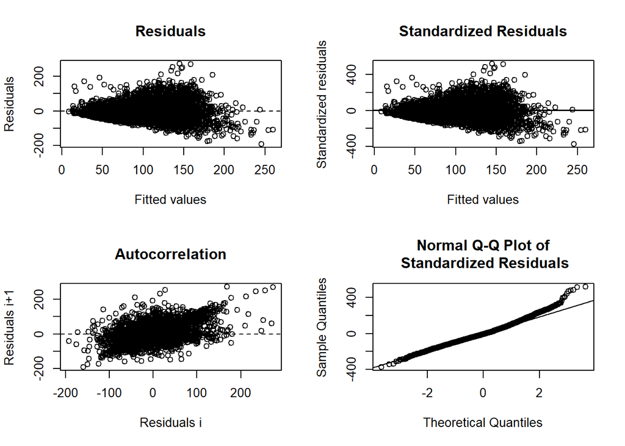

```
##
## ------
##  Shapiro-Wilk normality test
##
## data:  stdres
## W = 0.98653, p-value < 2.2e-16
##
##
## ------
```

```
##
##  Runs Test
##
## data:  as.factor(run)
## Standard Normal = -27.484, p-value < 2.2e-16
## alternative hypothesis: two.sided
```

## predict and plot

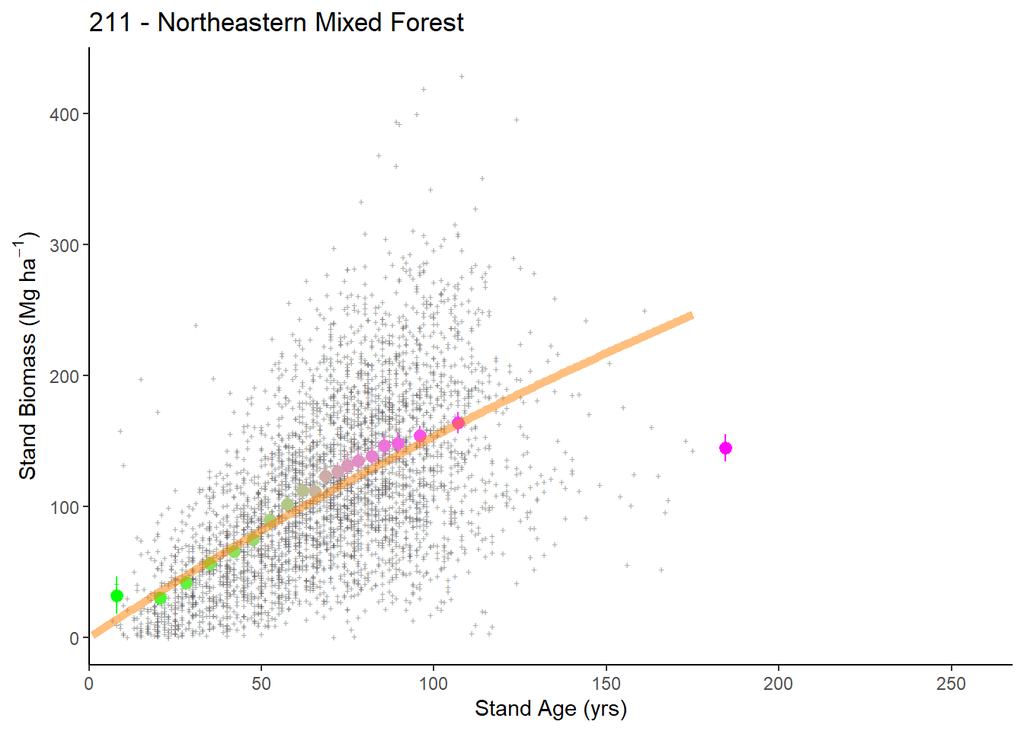

## plotting 2

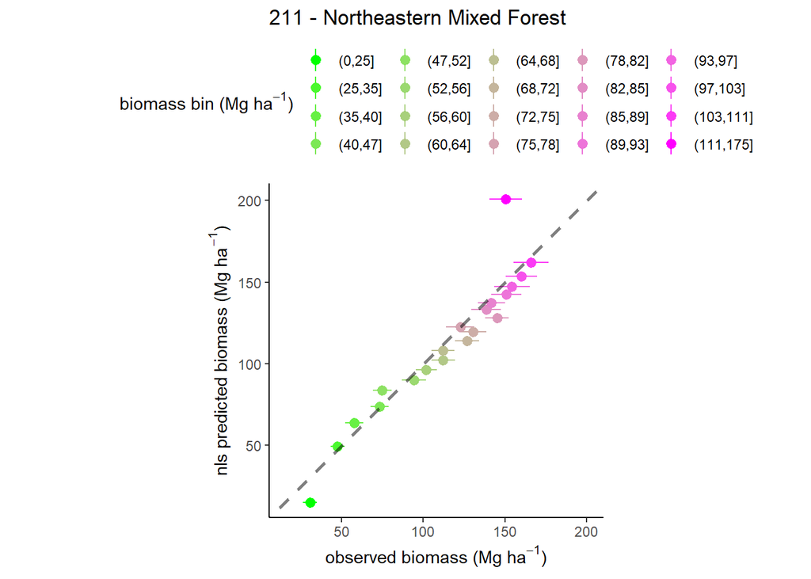

# 212 - Laurentian Mixed Forest

## model selection 1

```
## Analysis of Variance Table
##
## Model 1: B_plt_t1_MgHa ~ (1 + (MEASTIME_t2 - 1990) * ge/100) * A * STDAGE_t2/(k + STDAGE_t2)
## Model 2: B_plt_t1_MgHa ~ (1 + (MEASTIME_t2 - 1990) * ge/100) * (1 + phi * DeltaPDSI) * A * STDAGE_t2/(k + STDAGE_t2)
## Model 3: B_plt_t1_MgHa ~ (1 + (MEASTIME_t2 - 1990) * ge/100) * (1 + phi * DeltaPDSI) * (1 - alpha * B_L_prop) * A * STDAGE_t2/(k + STDAGE_t2)
##   Res.Df Res.Sum Sq Df  Sum Sq F value  Pr(>F)
## 1   9650     3885.9
## 2   9647     3885.7  3 0.14432  0.1194 0.94871
## 3   9646     3883.2  1 2.53950  6.3082 0.01203 *
## ---
## Signif. codes:  0 '***' 0.001 '**' 0.01 '*' 0.05 '.' 0.1 ' ' 1
##   model      AIC
## 1     1 100585.8
## 2     2 100567.2
## 3     3 100562.9
```

```
##
## Formula: B_plt_t1_MgHa ~ (1 + (MEASTIME_t2 - 1990) * ge/100) * (1 + phi *
##     DeltaPDSI) * (1 - alpha * B_L_prop) * A * STDAGE_t2/(k +
##     STDAGE_t2)
##
## Parameters:
##         Estimate Std. Error t value Pr(>|t|)
## ge      0.188694   0.144886   1.302   0.1928
## phi    -0.002906   0.005683  -0.511   0.6092
## alpha   0.142204   0.056322   2.525   0.0116 *
## A     232.140776  12.386036  18.742   <2e-16 ***
## k     136.808298   8.027474  17.043   <2e-16 ***
## ---
## Signif. codes:  0 '***' 0.001 '**' 0.01 '*' 0.05 '.' 0.1 ' ' 1
##
## Residual standard error: 0.6345 on 9646 degrees of freedom
##
## Number of iterations to convergence: 7
## Achieved convergence tolerance: 2.503e-06
##   (7 observations deleted due to missingness)
```

### summary

- simple model: fits
- phi model: fits
- phi-alpha model: fits

## model selection 2

```
## Error in numericDeriv(form[[3L]], names(ind), env, central = nDcentral) :
##   Missing value or an infinity produced when evaluating the model
## Analysis of Variance Table
##
## Model 1: B_plt_t1_MgHa ~ (1 + (MEASTIME_t2 - 1990) * ge/100) * (1 + phi * DeltaPDSI) * (1 - alpha * B_L_prop) * A * STDAGE_t2/(k + STDAGE_t2)
## Model 2: B_plt_t1_MgHa ~ (1 + (MEASTIME_t2 - 1990) * ge/100) * (1 + phi * DeltaPDSI) * (1 - alpha * B_L_prop) * (p * A + ((1 - p) * A * STDAGE_t2/(k + STDAGE_t2)))
##   Res.Df Res.Sum Sq Df Sum Sq F value  Pr(>F)
## 1   9646     3883.2
## 2   9645     3881.9  1 1.2802  3.1808 0.07454 .
## ---
## Signif. codes:  0 '***' 0.001 '**' 0.01 '*' 0.05 '.' 0.1 ' ' 1
##   model      AIC
## 1     3 100562.9
## 2    3a 100561.7
## 3    3b 100477.7
## 4    3c       NA
```

```
##
## Formula: B_plt_t1_MgHa ~ (1 + (MEASTIME_t2 - 1990) * ge/100) * (1 + phi *
##     DeltaPDSI) * (1 - alpha * B_L_prop) * (A * STDAGE_t2^s/(k^s +
##     STDAGE_t2^s))
##
## Parameters:
##         Estimate Std. Error t value Pr(>|t|)
## ge      0.200785   0.144733   1.387  0.16539
## phi    -0.003536   0.005626  -0.629  0.52965
## alpha   0.157993   0.057718   2.737  0.00621 **
## A     138.666585   7.605677  18.232  < 2e-16 ***
## k      54.579021   3.784099  14.423  < 2e-16 ***
## s       1.385515   0.046477  29.811  < 2e-16 ***
## ---
## Signif. codes:  0 '***' 0.001 '**' 0.01 '*' 0.05 '.' 0.1 ' ' 1
##
## Residual standard error: 0.6317 on 9645 degrees of freedom
##
## Number of iterations to convergence: 10
## Achieved convergence tolerance: 7.331e-06
##   (7 observations deleted due to missingness)
```

### summary

- add p model: fits
- add s model: fits
- add s+p model: does not fit

## plot residuals

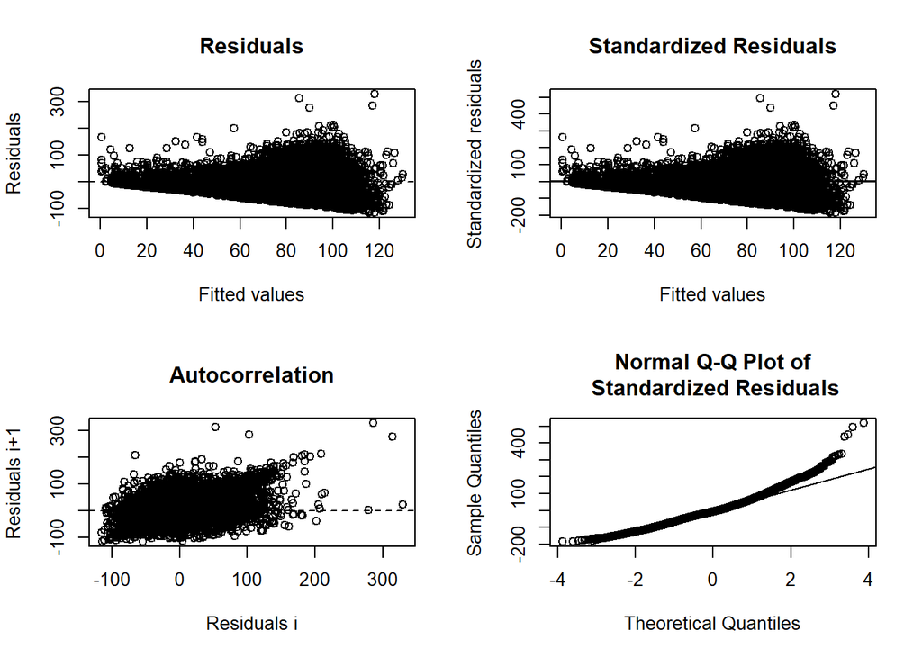

## predict and plot

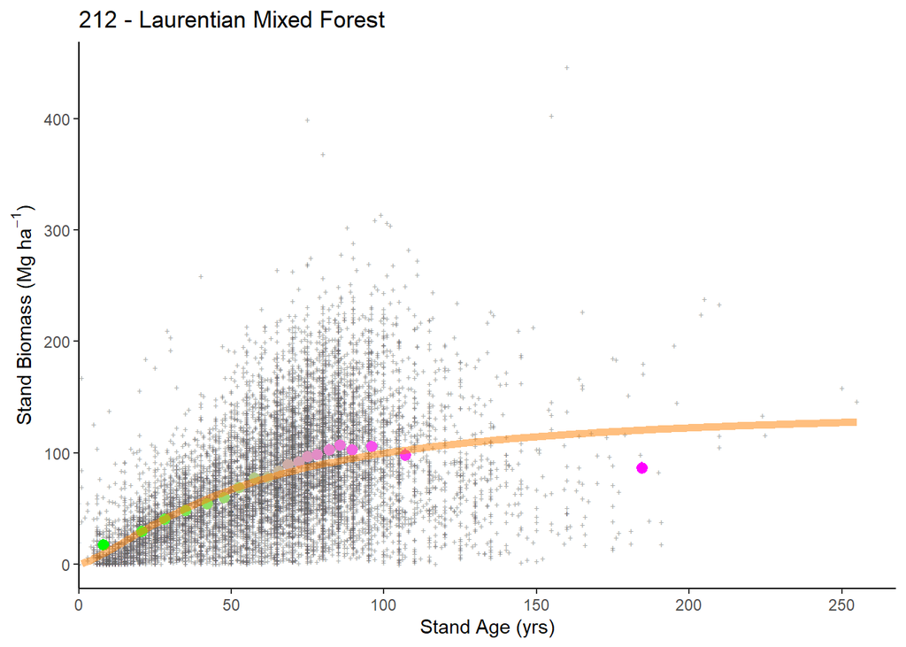

## plotting 2

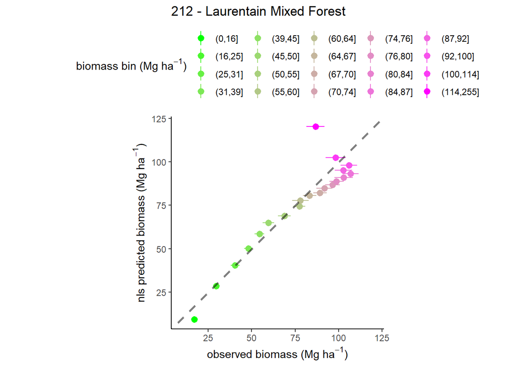

# 221 - Eastern Broadleaf Forest

## model selection 1

```
## Analysis of Variance Table
##
## Model 1: B_plt_t1_MgHa ~ (1 + (MEASTIME_t2 - 1990) * ge/100) * A * STDAGE_t2/(k + STDAGE_t2)
## Model 2: B_plt_t1_MgHa ~ (1 + (MEASTIME_t2 - 1990) * ge/100) * (1 + phi * DeltaPDSI) * A * STDAGE_t2/(k + STDAGE_t2)
## Model 3: B_plt_t1_MgHa ~ (1 + (MEASTIME_t2 - 1990) * ge/100) * (1 + phi * DeltaPDSI) * (1 - alpha * B_L_prop) * A * STDAGE_t2/(k + STDAGE_t2)
##   Res.Df Res.Sum Sq Df  Sum Sq F value Pr(>F)
## 1   4382     790.34
## 2   4381     790.28  1 0.06414  0.3556 0.5510
## 3   4374     788.14  7 2.13660  1.6939 0.1057
##   model      AIC
## 1     1 47744.21
## 2     2 47745.86
## 3     3 47687.70
```

```
##
## Formula: B_plt_t1_MgHa ~ (1 + (MEASTIME_t2 - 1990) * ge/100) * (1 + phi *
##     DeltaPDSI) * (1 - alpha * B_L_prop) * A * STDAGE_t2/(k +
##     STDAGE_t2)
##
## Parameters:
##         Estimate Std. Error t value Pr(>|t|)
## ge      0.106346   0.159119   0.668    0.504
## phi    -0.003667   0.006622  -0.554    0.580
## alpha  -0.052489   0.064755  -0.811    0.418
## A     713.180380  80.058353   8.908  < 2e-16 ***
## k     291.633063  36.406073   8.011 1.45e-15 ***
## ---
## Signif. codes:  0 '***' 0.001 '**' 0.01 '*' 0.05 '.' 0.1 ' ' 1
##
## Residual standard error: 0.4245 on 4374 degrees of freedom
##
## Number of iterations to convergence: 7
## Achieved convergence tolerance: 6.671e-06
##   (7 observations deleted due to missingness)
```

### summary

- simple model: fits
- phi model: fits
- phi-alpha model: fits

## model selection 2

```
## Error in numericDeriv(form[[3L]], names(ind), env, central = nDcentral) :
##   Missing value or an infinity produced when evaluating the model
## Error in numericDeriv(form[[3L]], names(ind), env, central = nDcentral) :
##   Missing value or an infinity produced when evaluating the model
## Analysis of Variance Table
##
## Model 1: B_plt_t1_MgHa ~ (1 + (MEASTIME_t2 - 1990) * ge/100) * (1 + phi * DeltaPDSI) * (1 - alpha * B_L_prop) * A * STDAGE_t2/(k + STDAGE_t2)
## Model 2: B_plt_t1_MgHa ~ (1 + (MEASTIME_t2 - 1990) * ge/100) * (1 + phi * DeltaPDSI) * (1 - alpha * B_L_prop) * (p * A + ((1 - p) * A * STDAGE_t2/(k + STDAGE_t2)))
##   Res.Df Res.Sum Sq Df Sum Sq F value   Pr(>F)
## 1   4374     788.14
## 2   4373     786.85  1 1.2898   7.168 0.007449 **
## ---
## Signif. codes:  0 '***' 0.001 '**' 0.01 '*' 0.05 '.' 0.1 ' ' 1
##   model      AIC
## 1     3 47687.70
## 2    3a 47682.52
## 3    3b       NA
## 4    3c       NA
```

```
##
## Formula: B_plt_t1_MgHa ~ (1 + (MEASTIME_t2 - 1990) * ge/100) * (1 + phi *
##     DeltaPDSI) * (1 - alpha * B_L_prop) * (p * A + ((1 - p) *
##     A * STDAGE_t2/(k + STDAGE_t2)))
##
## Parameters:
##         Estimate Std. Error t value Pr(>|t|)
## ge      0.125040   0.160588   0.779   0.4362
## phi    -0.003866   0.006613  -0.585   0.5588
## alpha  -0.033507   0.065005  -0.515   0.6063
## A     564.782827  70.879987   7.968 2.04e-15 ***
## k     204.212541  35.214124   5.799 7.13e-09 ***
## p      -0.013596   0.007043  -1.931   0.0536 .
## ---
## Signif. codes:  0 '***' 0.001 '**' 0.01 '*' 0.05 '.' 0.1 ' ' 1
##
## Residual standard error: 0.4242 on 4373 degrees of freedom
##
## Number of iterations to convergence: 9
## Achieved convergence tolerance: 7.859e-06
##   (7 observations deleted due to missingness)
```

### summary

- add p model: fits
- add s model: does not fit
- add s+p model: does not fit

## plot residuals

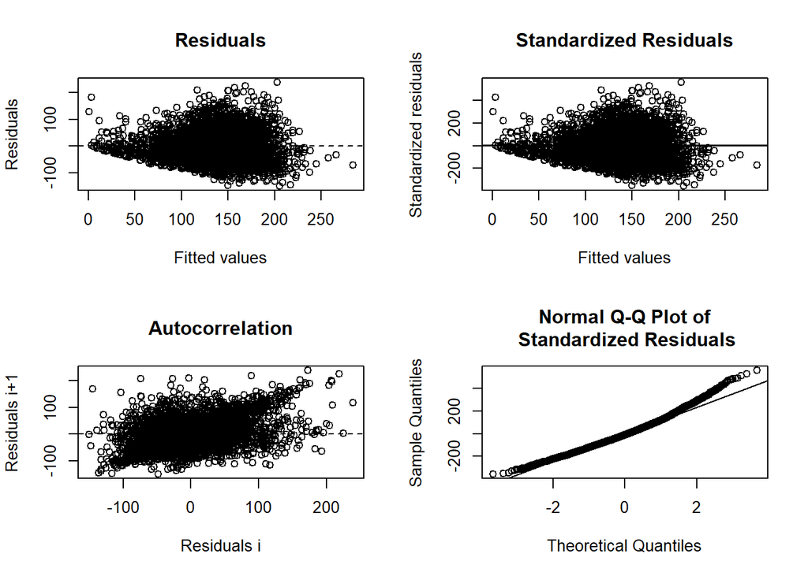

```
##
## ------
##  Shapiro-Wilk normality test
##
## data:  stdres
## W = 0.98529, p-value < 2.2e-16
##
##
## ------
```

```
##
##  Runs Test
##
## data:  as.factor(run)
## Standard Normal = -27.254, p-value < 2.2e-16
## alternative hypothesis: two.sided
```

## predict and plot

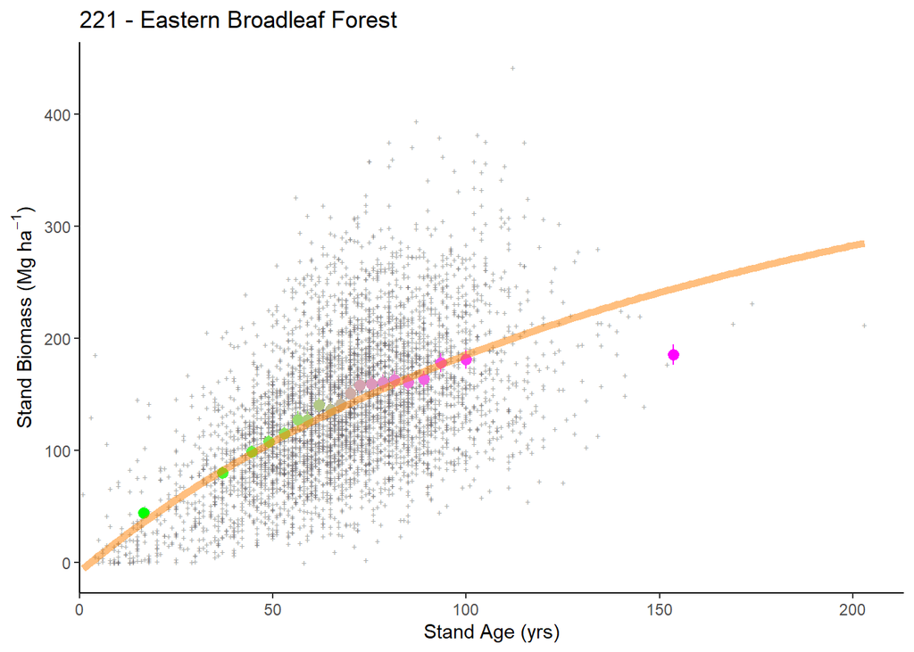

## plotting 2

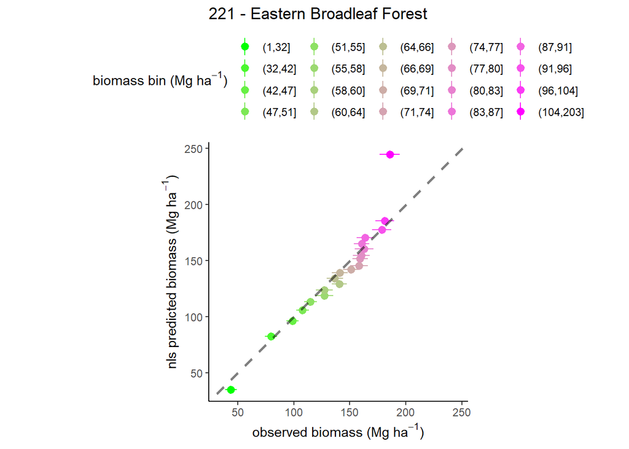

# 222 - Midwest Broadleaf Forest

## model selection 1

```
## Analysis of Variance Table
##
## Model 1: B_plt_t1_MgHa ~ (1 + (MEASTIME_t2 - 1990) * ge/100) * A * STDAGE_t2/(k + STDAGE_t2)
## Model 2: B_plt_t1_MgHa ~ (1 + (MEASTIME_t2 - 1990) * ge/100) * (1 + phi * DeltaPDSI) * A * STDAGE_t2/(k + STDAGE_t2)
## Model 3: B_plt_t1_MgHa ~ (1 + (MEASTIME_t2 - 1990) * ge/100) * (1 + phi * DeltaPDSI) * (1 - alpha * B_L_prop) * A * STDAGE_t2/(k + STDAGE_t2)
##   Res.Df Res.Sum Sq Df Sum Sq F value   Pr(>F)
## 1   2572     903.75
## 2   2571     900.73  1 3.0238  8.6310 0.003334 **
## 3   2568     898.74  3 1.9929  1.8981 0.127750
## ---
## Signif. codes:  0 '***' 0.001 '**' 0.01 '*' 0.05 '.' 0.1 ' ' 1
```

```
##   model      AIC
## 1     1 27646.25
## 2     2 27639.62
## 3     3 27622.27
```

```
##
## Formula: B_plt_t1_MgHa ~ (1 + (MEASTIME_t2 - 1990) * ge/100) * (1 + phi *
##     DeltaPDSI) * (1 - alpha * B_L_prop) * A * STDAGE_t2/(k +
##     STDAGE_t2)
##
## Parameters:
##         Estimate Std. Error t value Pr(>|t|)
## ge    -1.695e-01  2.763e-01  -0.614  0.53948
## phi    4.339e-02  1.535e-02   2.827  0.00473 **
## alpha  1.773e-01  9.043e-02   1.961  0.05003 .
## A      6.364e+03  1.182e+04   0.538  0.59038
## k      4.374e+03  8.211e+03   0.533  0.59431
## ---
## Signif. codes:  0 '***' 0.001 '**' 0.01 '*' 0.05 '.' 0.1 ' ' 1
##
## Residual standard error: 0.5916 on 2568 degrees of freedom
##
## Number of iterations to convergence: 9
## Achieved convergence tolerance: 5.831e-06
##   (3 observations deleted due to missingness)
```

### summary

- simple model: fits
- phi model: fits
- phi-alpha model: fits

## model selection 2

```
## Error in nls(get(paste("f_", Mod.Sel1, "a", sep = "")), data = G_222,  :
##   singular gradient
## Error in numericDeriv(form[[3L]], names(ind), env, central = nDcentral) :
##   Missing value or an infinity produced when evaluating the model
## Error in numericDeriv(form[[3L]], names(ind), env, central = nDcentral) :
##   Missing value or an infinity produced when evaluating the model
##   model      AIC
## 1     3 27622.27
## 2    3a       NA
## 3    3b       NA
## 4    3c       NA
```

```
##
## Formula: B_plt_t1_MgHa ~ (1 + (MEASTIME_t2 - 1990) * ge/100) * (1 + phi *
##     DeltaPDSI) * (1 - alpha * B_L_prop) * A * STDAGE_t2/(k +
##     STDAGE_t2)
##
## Parameters:
##         Estimate Std. Error t value Pr(>|t|)
## ge    -1.695e-01  2.763e-01  -0.614  0.53948
## phi    4.339e-02  1.535e-02   2.827  0.00473 **
## alpha  1.773e-01  9.043e-02   1.961  0.05003 .
## A      6.364e+03  1.182e+04   0.538  0.59038
## k      4.374e+03  8.211e+03   0.533  0.59431
## ---
## Signif. codes:  0 '***' 0.001 '**' 0.01 '*' 0.05 '.' 0.1 ' ' 1
##
## Residual standard error: 0.5916 on 2568 degrees of freedom
##
## Number of iterations to convergence: 9
## Achieved convergence tolerance: 5.831e-06
##   (3 observations deleted due to missingness)
```

### summary

- add p model: does not fit
- add s model: does not fit
- add s+p model: does not fit

## plot residuals

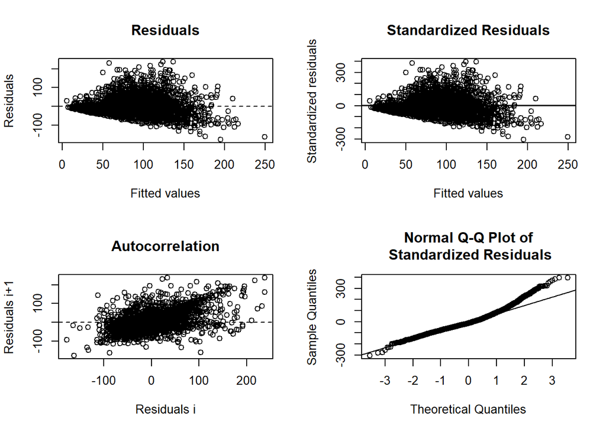

```
##
## ------
##  Shapiro-Wilk normality test
##
## data:  stdres
## W = 0.96069, p-value < 2.2e-16
##
##
## ------
```

```
##
##  Runs Test
##
## data:  as.factor(run)
## Standard Normal = -21.913, p-value < 2.2e-16
## alternative hypothesis: two.sided
```

## predict and plot

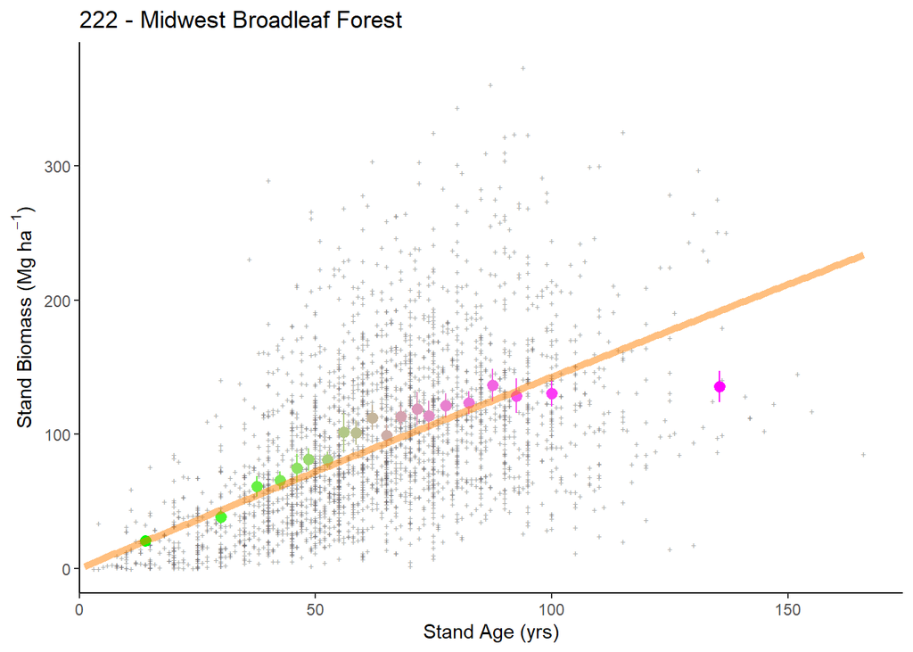

## plotting 2

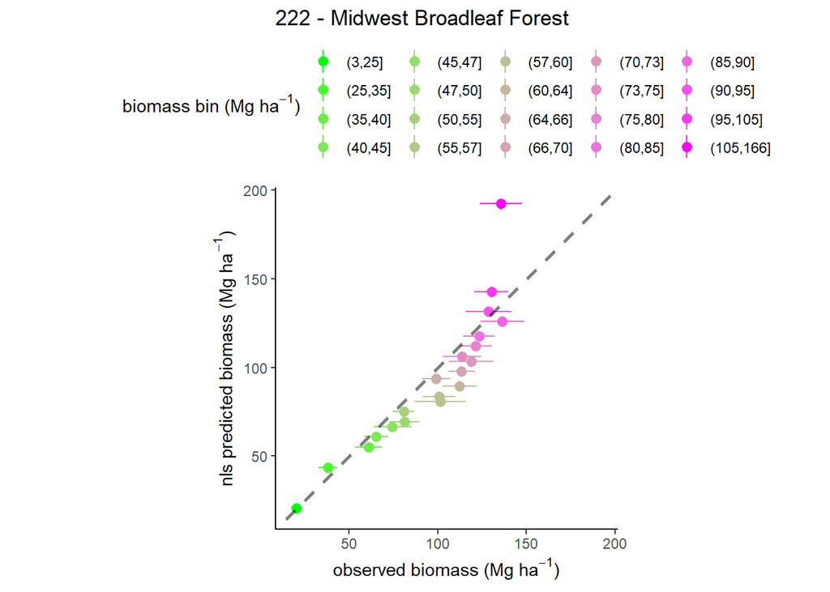

# 223 - Central Interior Broadleaf Forest

## model selection 1

```
## Error in nls(f_3, data = G_223, start = c(ge = ge.start, phi = phi.start,  :
##   step factor 0.000488281 reduced below 'minFactor' of 0.000976562
## Analysis of Variance Table
##
## Model 1: B_plt_t1_MgHa ~ (1 + (MEASTIME_t2 - 1990) * ge/100) * A * STDAGE_t2/(k + STDAGE_t2)
## Model 2: B_plt_t1_MgHa ~ (1 + (MEASTIME_t2 - 1990) * ge/100) * (1 + phi * DeltaPDSI) * A * STDAGE_t2/(k + STDAGE_t2)
##   Res.Df Res.Sum Sq Df    Sum Sq F value Pr(>F)
## 1   5018     918.97
## 2   5017     918.96  1 0.0093466   0.051 0.8213
##   model      AIC
## 1     1 51998.01
## 2     2 51999.95
## 3     3       NA
```

```
##
## Formula: B_plt_t1_MgHa ~ (1 + (MEASTIME_t2 - 1990) * ge/100) * A * STDAGE_t2/(k +
##     STDAGE_t2)
##
## Parameters:
##     Estimate Std. Error t value Pr(>|t|)
## ge  -0.09275    0.11339  -0.818    0.413
## A  343.73951   22.45391  15.309   <2e-16 ***
## k  145.00207   11.58140  12.520   <2e-16 ***
## ---
## Signif. codes:  0 '***' 0.001 '**' 0.01 '*' 0.05 '.' 0.1 ' ' 1
##
## Residual standard error: 0.4279 on 5018 degrees of freedom
##
## Number of iterations to convergence: 7
## Achieved convergence tolerance: 4.024e-06
##   (3 observations deleted due to missingness)
```

### summary

- simple model: fits
- phi model: fits
- phi-alpha model: does not fit

## model selection 2

```
## Error in numericDeriv(form[[3L]], names(ind), env, central = nDcentral) :
##   Missing value or an infinity produced when evaluating the model
## Error in numericDeriv(form[[3L]], names(ind), env, central = nDcentral) :
##   Missing value or an infinity produced when evaluating the model
## Analysis of Variance Table
##
## Model 1: B_plt_t1_MgHa ~ (1 + (MEASTIME_t2 - 1990) * ge/100) * A * STDAGE_t2/(k + STDAGE_t2)
## Model 2: B_plt_t1_MgHa ~ (1 + (MEASTIME_t2 - 1990) * ge/100) * (p * A + ((1 - p) * A * STDAGE_t2/(k + STDAGE_t2)))
##   Res.Df Res.Sum Sq Df Sum Sq F value    Pr(>F)
## 1   5018     918.97
## 2   5017     914.27  1 4.6984  25.782 3.961e-07 ***
## ---
## Signif. codes:  0 '***' 0.001 '**' 0.01 '*' 0.05 '.' 0.1 ' ' 1
##   model      AIC
## 1     1 51998.01
## 2    1a 51974.27
## 3    1b       NA
## 4    1c       NA
```

```
##
## Formula: B_plt_t1_MgHa ~ (1 + (MEASTIME_t2 - 1990) * ge/100) * (p * A +
##     ((1 - p) * A * STDAGE_t2/(k + STDAGE_t2)))
##
## Parameters:
##     Estimate Std. Error t value Pr(>|t|)
## ge  -0.08953    0.11318  -0.791 0.428951
## A  274.35762   18.52203  14.813  < 2e-16 ***
## k   89.06450   10.88555   8.182 3.51e-16 ***
## p   -0.05233    0.01509  -3.468 0.000529 ***
## ---
## Signif. codes:  0 '***' 0.001 '**' 0.01 '*' 0.05 '.' 0.1 ' ' 1
##
## Residual standard error: 0.4269 on 5017 degrees of freedom
##
## Number of iterations to convergence: 9
## Achieved convergence tolerance: 3.736e-06
##   (3 observations deleted due to missingness)
```

### summary

- add p model: fits
- add s model: does not fit
- add s+p model: does not fit

## plot residuals

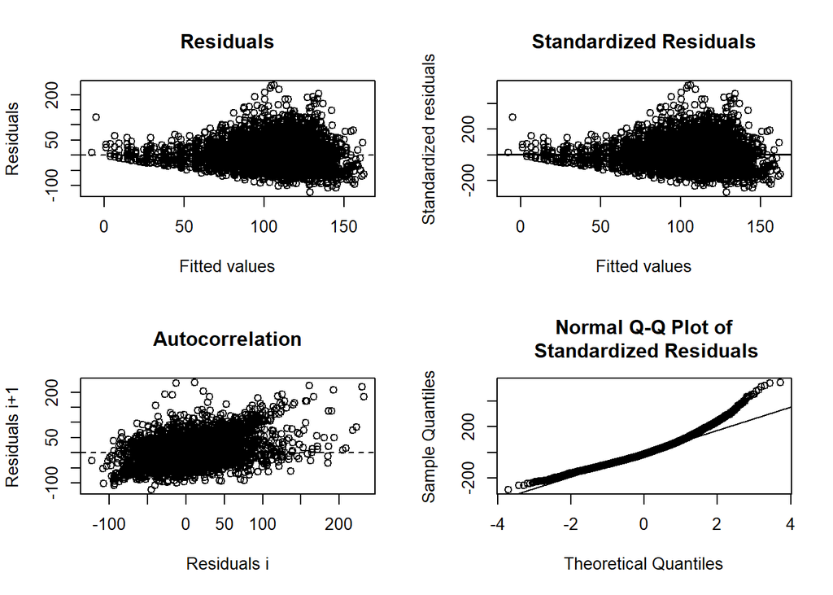

## predict and plot

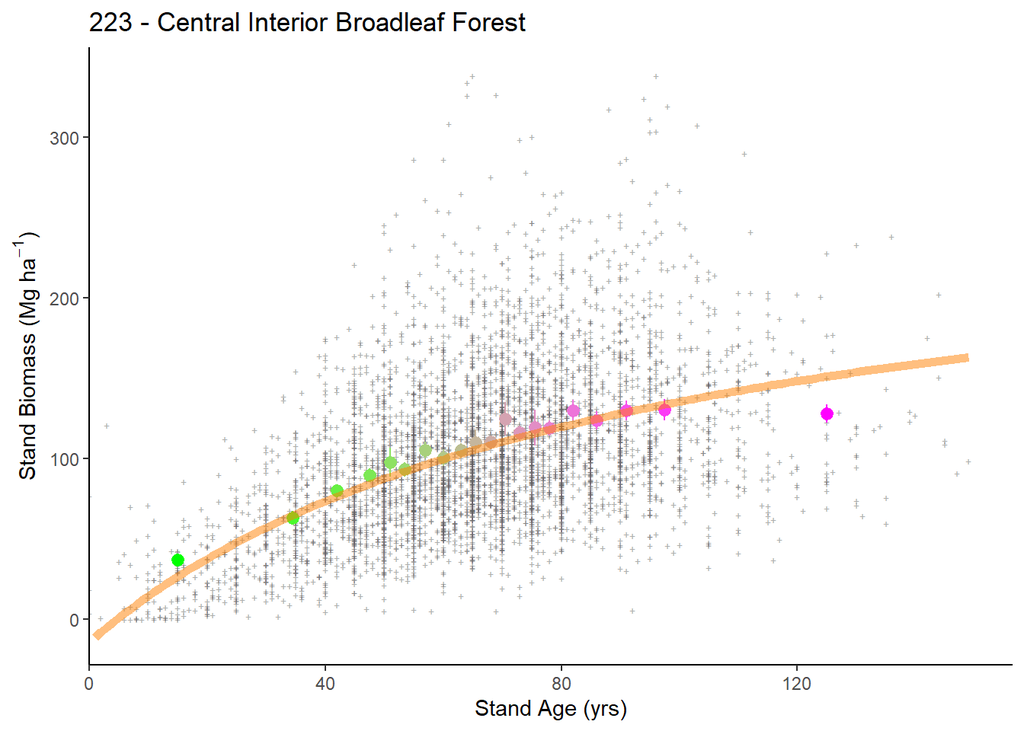

## plotting 2

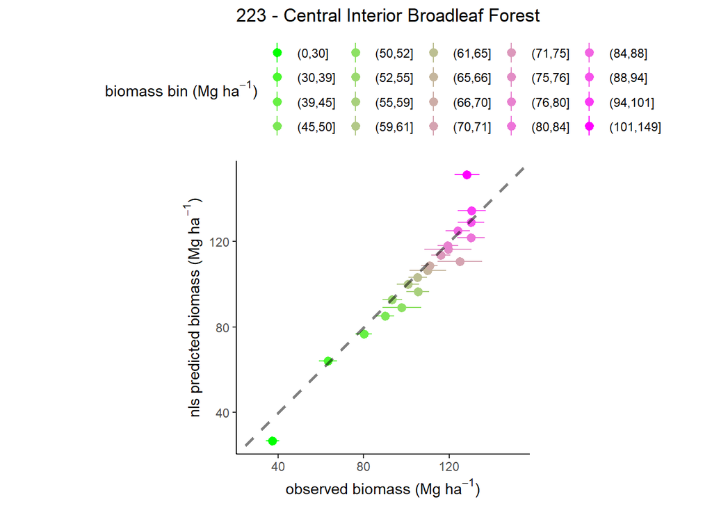

# 231 - Southeastern Mixed Forest

## model selection 1

```
## Analysis of Variance Table
##
## Model 1: B_plt_t1_MgHa ~ (1 + (MEASTIME_t2 - 1990) * ge/100) * A * STDAGE_t2/(k + STDAGE_t2)
## Model 2: B_plt_t1_MgHa ~ (1 + (MEASTIME_t2 - 1990) * ge/100) * (1 + phi * DeltaPDSI) * A * STDAGE_t2/(k + STDAGE_t2)
## Model 3: B_plt_t1_MgHa ~ (1 + (MEASTIME_t2 - 1990) * ge/100) * (1 + phi * DeltaPDSI) * (1 - alpha * B_L_prop) * A * STDAGE_t2/(k + STDAGE_t2)
##   Res.Df Res.Sum Sq Df  Sum Sq F value Pr(>F)
## 1   5946     1719.7
## 2   5945     1719.2  1 0.41652  1.4403 0.2301
## 3   5944     1719.2  1 0.01545  0.0534 0.8173
##   model      AIC
## 1     1 64096.84
## 2     2 64097.40
## 3     3 64099.35
```

```
##
## Formula: B_plt_t1_MgHa ~ (1 + (MEASTIME_t2 - 1990) * ge/100) * A * STDAGE_t2/(k +
##     STDAGE_t2)
##
## Parameters:
##    Estimate Std. Error t value Pr(>|t|)
## ge   0.3206     0.1315   2.438   0.0148 *
## A  795.0559    88.6528   8.968   <2e-16 ***
## k  328.4986    39.1332   8.394   <2e-16 ***
## ---
## Signif. codes:  0 '***' 0.001 '**' 0.01 '*' 0.05 '.' 0.1 ' ' 1
##
## Residual standard error: 0.5378 on 5946 degrees of freedom
##
## Number of iterations to convergence: 6
## Achieved convergence tolerance: 7.994e-06
##   (3 observations deleted due to missingness)
```

### summary

- simple model: fits
- phi model: fits
- phi-alpha model: fits

## model selection 2

```
## Error in numericDeriv(form[[3L]], names(ind), env, central = nDcentral) :
##   Missing value or an infinity produced when evaluating the model
## Error in numericDeriv(form[[3L]], names(ind), env, central = nDcentral) :
##   Missing value or an infinity produced when evaluating the model
## Analysis of Variance Table
##
## Model 1: B_plt_t1_MgHa ~ (1 + (MEASTIME_t2 - 1990) * ge/100) * A * STDAGE_t2/(k + STDAGE_t2)
## Model 2: B_plt_t1_MgHa ~ (1 + (MEASTIME_t2 - 1990) * ge/100) * (p * A + ((1 - p) * A * STDAGE_t2/(k + STDAGE_t2)))
##   Res.Df Res.Sum Sq Df Sum Sq F value   Pr(>F)
## 1   5946     1719.7
## 2   5945     1717.3  1 2.3248  8.0478 0.004571 **
## ---
## Signif. codes:  0 '***' 0.001 '**' 0.01 '*' 0.05 '.' 0.1 ' ' 1
##   model      AIC
## 1     1 64096.84
## 2    1a 64090.80
## 3    1b       NA
## 4    1c       NA
```

```
##
## Formula: B_plt_t1_MgHa ~ (1 + (MEASTIME_t2 - 1990) * ge/100) * (p * A +
##     ((1 - p) * A * STDAGE_t2/(k + STDAGE_t2)))
##
## Parameters:
##      Estimate Std. Error t value Pr(>|t|)
## ge   0.302012   0.130728   2.310   0.0209 *
## A  619.617521  76.320200   8.119 5.68e-16 ***
## k  234.371676  36.281468   6.460 1.13e-10 ***
## p   -0.004594   0.002242  -2.049   0.0405 *
## ---
## Signif. codes:  0 '***' 0.001 '**' 0.01 '*' 0.05 '.' 0.1 ' ' 1
##
## Residual standard error: 0.5375 on 5945 degrees of freedom
##
## Number of iterations to convergence: 7
## Achieved convergence tolerance: 9.628e-06
##   (3 observations deleted due to missingness)
```

### summary

- add p model: fits
- add s model: does not fit
- add s+p model: does not fit

## plot residuals

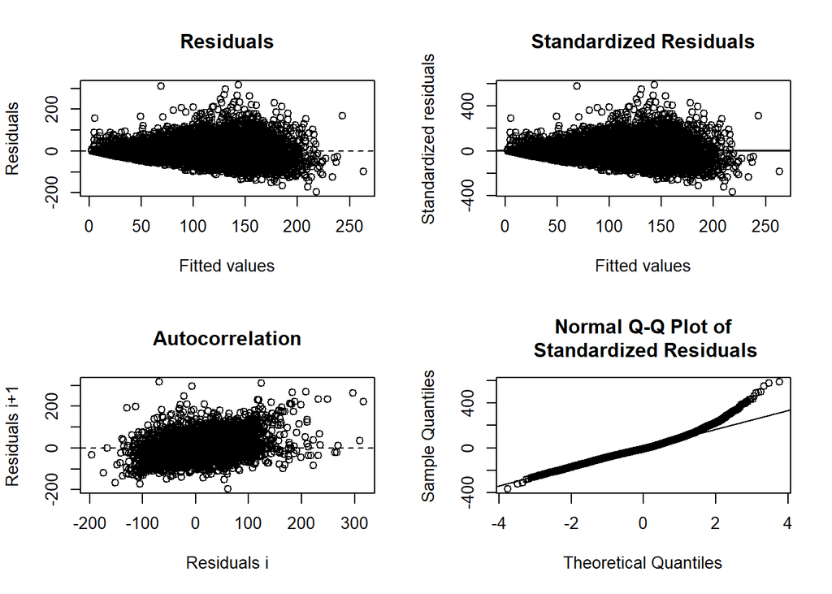

## predict and plot

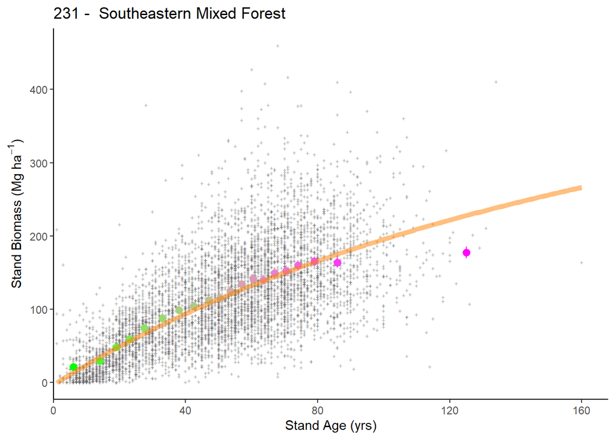

## plotting 2

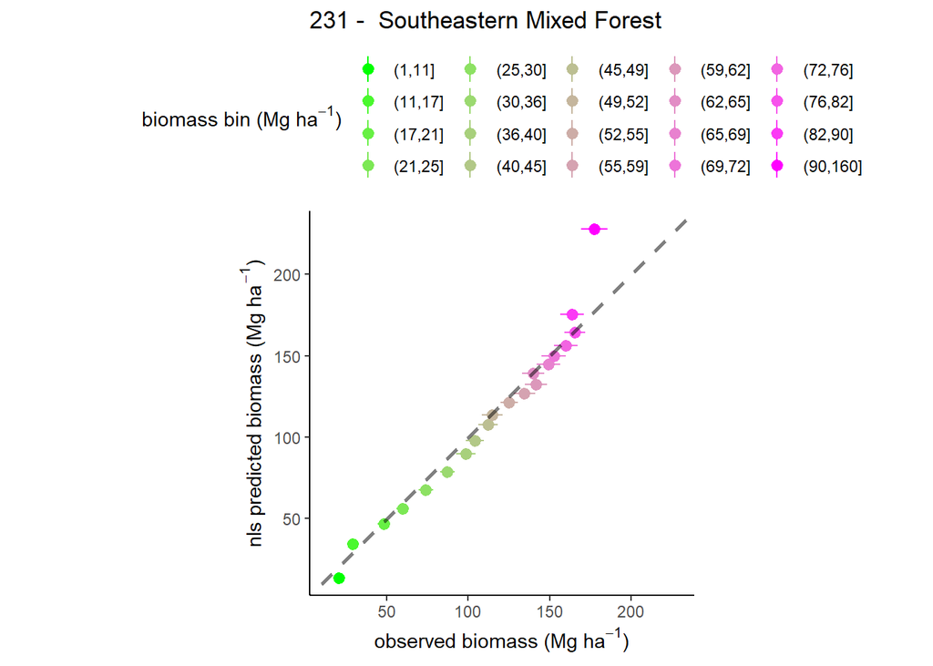

# 232 - Outer Coastal Plain Mixed Forest

## model selection 1

```
## Analysis of Variance Table
##
## Model 1: B_plt_t1_MgHa ~ (1 + (MEASTIME_t2 - 1990) * ge/100) * A * STDAGE_t2/(k + STDAGE_t2)
## Model 2: B_plt_t1_MgHa ~ (1 + (MEASTIME_t2 - 1990) * ge/100) * (1 + phi * DeltaPDSI) * A * STDAGE_t2/(k + STDAGE_t2)
## Model 3: B_plt_t1_MgHa ~ (1 + (MEASTIME_t2 - 1990) * ge/100) * (1 + phi * DeltaPDSI) * (1 - alpha * B_L_prop) * A * STDAGE_t2/(k + STDAGE_t2)
##   Res.Df Res.Sum Sq Df Sum Sq F value    Pr(>F)
## 1   6115     2830.9
## 2   6114     2825.2  1 5.6986 12.3324 0.0004484 ***
## 3   6113     2823.0  1 2.1547  4.6657 0.0308094 *
## ---
## Signif. codes:  0 '***' 0.001 '**' 0.01 '*' 0.05 '.' 0.1 ' ' 1
##   model      AIC
## 1     1 68012.14
## 2     2 68001.82
## 3     3 67999.15
```

```
##
## Formula: B_plt_t1_MgHa ~ (1 + (MEASTIME_t2 - 1990) * ge/100) * (1 + phi *
##     DeltaPDSI) * (1 - alpha * B_L_prop) * A * STDAGE_t2/(k +
##     STDAGE_t2)
##
## Parameters:
##        Estimate Std. Error t value Pr(>|t|)
## ge    1.494e-01  1.634e-01   0.914 0.360693
## phi   3.028e-02  8.724e-03   3.471 0.000521 ***
## alpha 1.419e-01  6.497e-02   2.184 0.029007 *
## A     8.917e+02  1.349e+02   6.611 4.15e-11 ***
## k     3.851e+02  6.160e+01   6.252 4.32e-10 ***
## ---
## Signif. codes:  0 '***' 0.001 '**' 0.01 '*' 0.05 '.' 0.1 ' ' 1
##
## Residual standard error: 0.6796 on 6113 degrees of freedom
##
## Number of iterations to convergence: 7
## Achieved convergence tolerance: 7.044e-06
##   (2 observations deleted due to missingness)
```

### summary

- simple model: fits
- phi model: fits
- phi-alpha model: fits

## model selection 2

```
## Error in nls(get(paste("f_", Mod.Sel1, "b", sep = "")), data = G_232,  :
##   singular gradient
## Error in numericDeriv(form[[3L]], names(ind), env, central = nDcentral) :
##   Missing value or an infinity produced when evaluating the model
## Analysis of Variance Table
##
## Model 1: B_plt_t1_MgHa ~ (1 + (MEASTIME_t2 - 1990) * ge/100) * (1 + phi * DeltaPDSI) * (1 - alpha * B_L_prop) * A * STDAGE_t2/(k + STDAGE_t2)
## Model 2: B_plt_t1_MgHa ~ (1 + (MEASTIME_t2 - 1990) * ge/100) * (1 + phi * DeltaPDSI) * (1 - alpha * B_L_prop) * (p * A + ((1 - p) * A * STDAGE_t2/(k + STDAGE_t2)))
##   Res.Df Res.Sum Sq Df Sum Sq F value  Pr(>F)
## 1   6113     2823.0
## 2   6112     2821.1  1 1.9352  4.1927 0.04064 *
## ---
## Signif. codes:  0 '***' 0.001 '**' 0.01 '*' 0.05 '.' 0.1 ' ' 1
##   model      AIC
## 1     3 67999.15
## 2    3a 67996.95
## 3    3b       NA
## 4    3c       NA
```

```
##
## Formula: B_plt_t1_MgHa ~ (1 + (MEASTIME_t2 - 1990) * ge/100) * (1 + phi *
##     DeltaPDSI) * (1 - alpha * B_L_prop) * (p * A + ((1 - p) *
##     A * STDAGE_t2/(k + STDAGE_t2)))
##
## Parameters:
##         Estimate Std. Error t value Pr(>|t|)
## ge      0.127419   0.162457   0.784 0.432878
## phi     0.030350   0.008724   3.479 0.000507 ***
## alpha   0.146920   0.065536   2.242 0.025008 *
## A     707.334071 119.028264   5.943 2.96e-09 ***
## k     283.002905  58.146514   4.867 1.16e-06 ***
## p      -0.003527   0.002376  -1.484 0.137802
## ---
## Signif. codes:  0 '***' 0.001 '**' 0.01 '*' 0.05 '.' 0.1 ' ' 1
##
## Residual standard error: 0.6794 on 6112 degrees of freedom
##
## Number of iterations to convergence: 9
## Achieved convergence tolerance: 4.877e-06
##   (2 observations deleted due to missingness)
```

### summary

- add p model: fits
- add s model: does not fit
- add s+p model: does not fit

## plot residuals

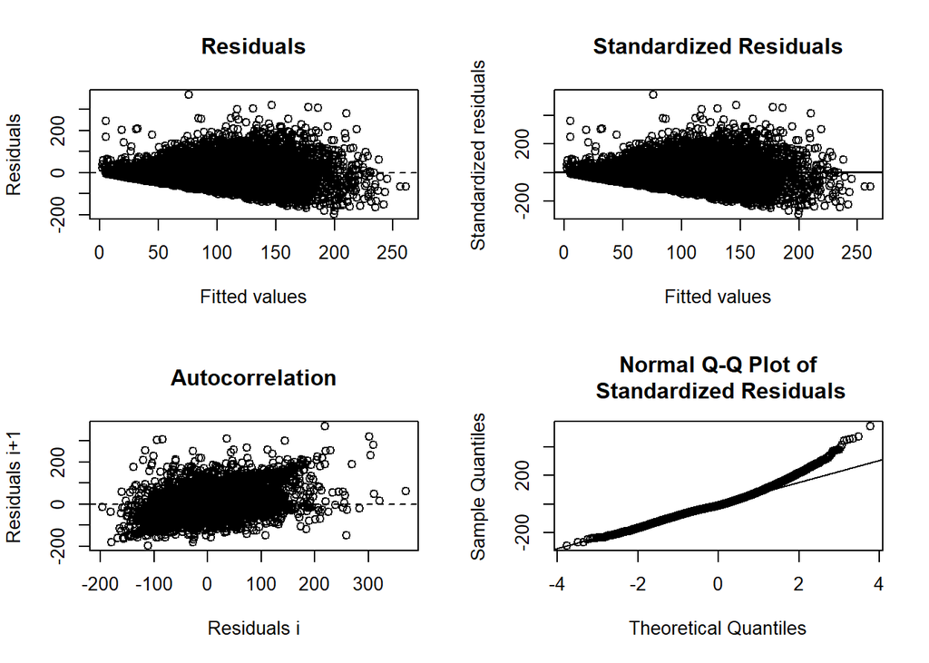

## predict and plot

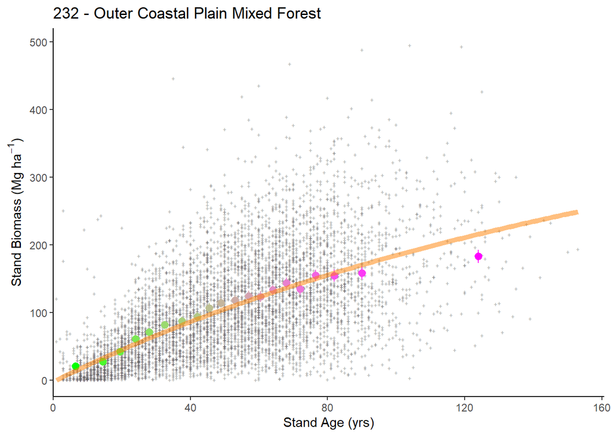

## plotting 2

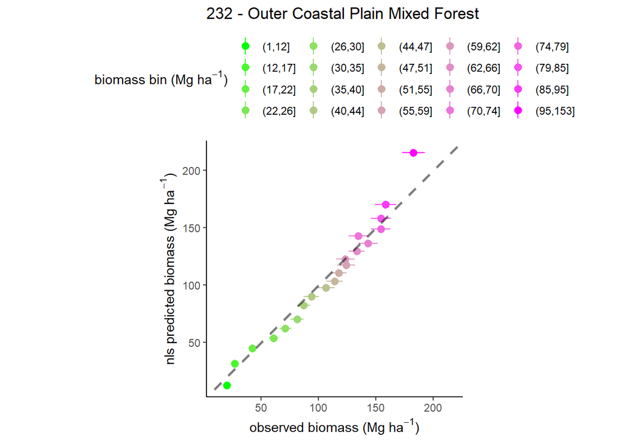

# 234 - Lower Mississippi Riverine Forest

## model selection 1

```
## Error in nls(f_1, data = G_234, start = c(ge = ge.start, A = A.start,  :
##   singular gradient
## Error in nls(f_2, data = G_234, start = c(ge = ge.start, phi = phi.start,  :
##   step factor 0.000488281 reduced below 'minFactor' of 0.000976562
## Error in nls(f_3, data = G_234, start = c(ge = ge.start, phi = phi.start,  :
##   singular gradient
##   model AIC
## 1     1  NA
## 2     2  NA
## 3     3  NA
```

```
## Error in h(simpleError(msg, call)) :
##   error in evaluating the argument 'object' in selecting a method for function 'summary': object 'nls_234.' not found
```

### summary

- simple model: does not fit
- phi model: does not fit
- phi-alpha model: does not fit

## model selection 2

### summary

- add p model: does not fit
- add s model: does not fit
- add s+p model: does not fit

## plot residuals

```
## [1] "cannot plot residuals"
```

## predict and plot

```
## [1] "cannot plot data with prediction"
```

## plotting 2

```
## [1] "cannot plot observed vs. predicted"
```

# 242 - Pacific Lowland Mixed Forest

## model selection 1

```
## Error in if (any(nEQ <- vNms != make.names(vNms))) vNms[nEQ] <- paste0("`",  :
##   missing value where TRUE/FALSE needed
## Error in if (any(nEQ <- vNms != make.names(vNms))) vNms[nEQ] <- paste0("`",  :
##   missing value where TRUE/FALSE needed
## Error in if (any(nEQ <- vNms != make.names(vNms))) vNms[nEQ] <- paste0("`",  :
##   missing value where TRUE/FALSE needed
##   model AIC
## 1     1  NA
## 2     2  NA
## 3     3  NA
```

```
## Error in h(simpleError(msg, call)) :
##   error in evaluating the argument 'object' in selecting a method for function 'summary': object 'nls_242.' not found
```

### summary

- simple model: does not fit
- phi model: does not fit
- phi-alpha model: does not fit

## model selection 2

### summary

- add p model: does not fit
- add s model: does not fit
- add s+p model: does not fit

## plot residuals

```
## [1] "cannot plot residuals"
```

## predict and plot

```
## [1] "cannot plot data with prediction"
```

## plotting 2

```
## [1] "cannot plot observed vs. predicted"
```

# 251 - Prairie Parkland (Temperate)

## model selection 1

```
## Analysis of Variance Table
##
## Model 1: B_plt_t1_MgHa ~ (1 + (MEASTIME_t2 - 1990) * ge/100) * A * STDAGE_t2/(k + STDAGE_t2)
## Model 2: B_plt_t1_MgHa ~ (1 + (MEASTIME_t2 - 1990) * ge/100) * (1 + phi * DeltaPDSI) * A * STDAGE_t2/(k + STDAGE_t2)
## Model 3: B_plt_t1_MgHa ~ (1 + (MEASTIME_t2 - 1990) * ge/100) * (1 + phi * DeltaPDSI) * (1 - alpha * B_L_prop) * A * STDAGE_t2/(k + STDAGE_t2)
##   Res.Df Res.Sum Sq Df  Sum Sq F value Pr(>F)
## 1   1108     285.97
## 2   1107     285.47  1 0.50344  1.9523 0.1626
## 3   1106     285.26  1 0.20552  0.7968 0.3722
##   model      AIC
## 1     1 11610.47
## 2     2 11610.52
## 3     3 11611.72
```

```
##
## Formula: B_plt_t1_MgHa ~ (1 + (MEASTIME_t2 - 1990) * ge/100) * A * STDAGE_t2/(k +
##     STDAGE_t2)
##
## Parameters:
##     Estimate Std. Error t value Pr(>|t|)
## ge   0.01395    0.31846   0.044    0.965
## A  310.82193   50.46482   6.159 1.02e-09 ***
## k  146.67835   28.22950   5.196 2.42e-07 ***
## ---
## Signif. codes:  0 '***' 0.001 '**' 0.01 '*' 0.05 '.' 0.1 ' ' 1
##
## Residual standard error: 0.508 on 1108 degrees of freedom
##
## Number of iterations to convergence: 7
## Achieved convergence tolerance: 2.249e-06
##   (1 observation deleted due to missingness)
```

### summary

- simple model: fits
- phi model: fits
- phi-alpha model: fits

## model selection 2

```
## Error in numericDeriv(form[[3L]], names(ind), env, central = nDcentral) :
##   Missing value or an infinity produced when evaluating the model
## Error in numericDeriv(form[[3L]], names(ind), env, central = nDcentral) :
##   Missing value or an infinity produced when evaluating the model
## Analysis of Variance Table
##
## Model 1: B_plt_t1_MgHa ~ (1 + (MEASTIME_t2 - 1990) * ge/100) * A * STDAGE_t2/(k + STDAGE_t2)
## Model 2: B_plt_t1_MgHa ~ (1 + (MEASTIME_t2 - 1990) * ge/100) * (p * A + ((1 - p) * A * STDAGE_t2/(k + STDAGE_t2)))
##   Res.Df Res.Sum Sq Df   Sum Sq F value Pr(>F)
## 1   1108     285.97
## 2   1107     285.90  1 0.067038  0.2596 0.6105
##   model      AIC
## 1     1 11610.47
## 2    1a 11612.21
## 3    1b       NA
## 4    1c       NA
```

```
##
## Formula: B_plt_t1_MgHa ~ (1 + (MEASTIME_t2 - 1990) * ge/100) * A * STDAGE_t2/(k +
##     STDAGE_t2)
##
## Parameters:
##     Estimate Std. Error t value Pr(>|t|)
## ge   0.01395    0.31846   0.044    0.965
## A  310.82193   50.46482   6.159 1.02e-09 ***
## k  146.67835   28.22950   5.196 2.42e-07 ***
## ---
## Signif. codes:  0 '***' 0.001 '**' 0.01 '*' 0.05 '.' 0.1 ' ' 1
##
## Residual standard error: 0.508 on 1108 degrees of freedom
##
## Number of iterations to convergence: 7
## Achieved convergence tolerance: 2.249e-06
##   (1 observation deleted due to missingness)
```

### summary

- add p model: fits
- add s model: does not fit
- add s+p model: does not fit

## plot residuals

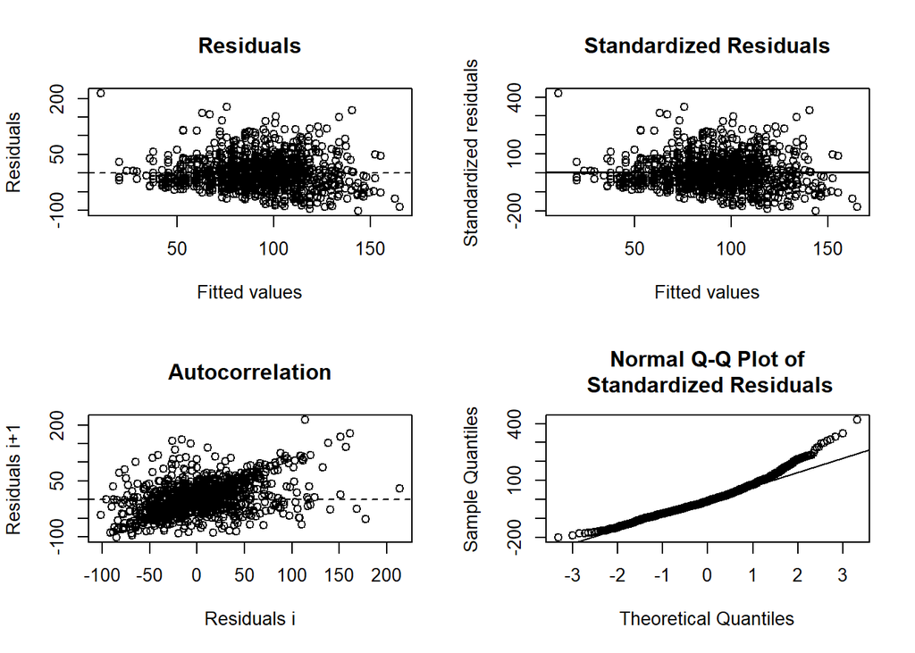

```
##
## ------
##  Shapiro-Wilk normality test
##
## data:  stdres
## W = 0.96647, p-value = 2.48e-15
##
##
## ------
```

```
##
##  Runs Test
##
## data:  as.factor(run)
## Standard Normal = -12.336, p-value < 2.2e-16
## alternative hypothesis: two.sided
```

## predict and plot

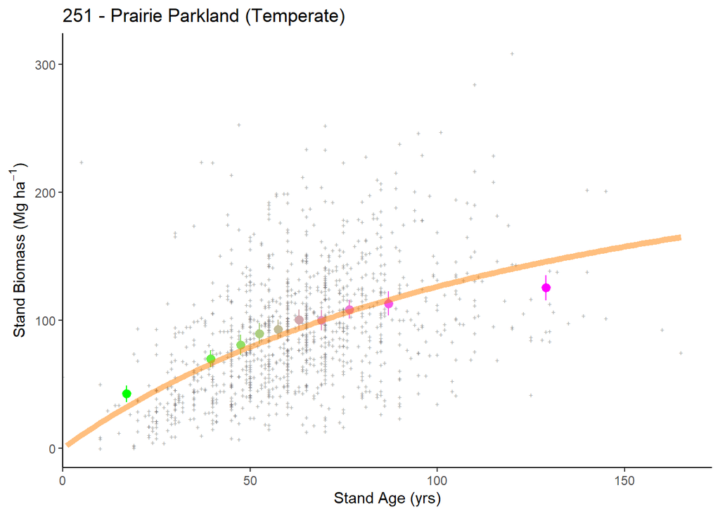

## plotting 2

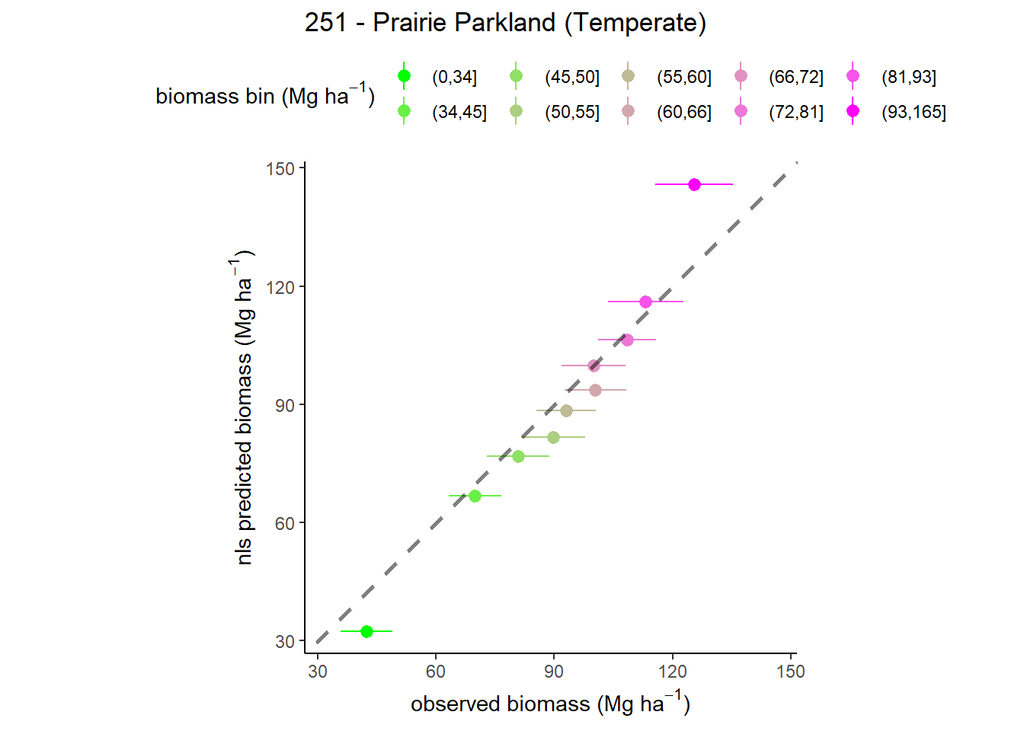

# 255 - Prairie Parkland (Subtropical)

## model selection 1

```
## Analysis of Variance Table
##
## Model 1: B_plt_t1_MgHa ~ (1 + (MEASTIME_t2 - 1990) * ge/100) * A * STDAGE_t2/(k + STDAGE_t2)
## Model 2: B_plt_t1_MgHa ~ (1 + (MEASTIME_t2 - 1990) * ge/100) * (1 + phi * DeltaPDSI) * A * STDAGE_t2/(k + STDAGE_t2)
## Model 3: B_plt_t1_MgHa ~ (1 + (MEASTIME_t2 - 1990) * ge/100) * (1 + phi * DeltaPDSI) * (1 - alpha * B_L_prop) * A * STDAGE_t2/(k + STDAGE_t2)
##   Res.Df Res.Sum Sq Df  Sum Sq F value Pr(>F)
## 1    378     174.30
## 2    377     173.75  1 0.54418  1.1807 0.2779
## 3    376     173.39  1 0.36603  0.7937 0.3735
##   model      AIC
## 1     1 3945.009
## 2     2 3945.818
## 3     3 3947.014
```

```
##
## Formula: B_plt_t1_MgHa ~ (1 + (MEASTIME_t2 - 1990) * ge/100) * A * STDAGE_t2/(k +
##     STDAGE_t2)
##
## Parameters:
##    Estimate Std. Error t value Pr(>|t|)
## ge  -0.6916     0.4512  -1.533  0.12613
## A  332.1951   117.9465   2.816  0.00511 **
## k  144.6351    61.0806   2.368  0.01839 *
## ---
## Signif. codes:  0 '***' 0.001 '**' 0.01 '*' 0.05 '.' 0.1 ' ' 1
##
## Residual standard error: 0.6791 on 378 degrees of freedom
##
## Number of iterations to convergence: 7
## Achieved convergence tolerance: 4.635e-06
##   (1 observation deleted due to missingness)
```

### summary

- simple model: fits
- phi model: fits
- phi-alpha model: fits

## model selection 2

```
## Error in numericDeriv(form[[3L]], names(ind), env, central = nDcentral) :
##   Missing value or an infinity produced when evaluating the model
## Error in numericDeriv(form[[3L]], names(ind), env, central = nDcentral) :
##   Missing value or an infinity produced when evaluating the model
## Analysis of Variance Table
##
## Model 1: B_plt_t1_MgHa ~ (1 + (MEASTIME_t2 - 1990) * ge/100) * A * STDAGE_t2/(k + STDAGE_t2)
## Model 2: B_plt_t1_MgHa ~ (1 + (MEASTIME_t2 - 1990) * ge/100) * (p * A + ((1 - p) * A * STDAGE_t2/(k + STDAGE_t2)))
##   Res.Df Res.Sum Sq Df   Sum Sq F value Pr(>F)
## 1    378     174.30
## 2    377     174.22  1 0.078298  0.1694 0.6809
##   model      AIC
## 1     1 3945.009
## 2    1a 3946.838
## 3    1b       NA
## 4    1c       NA
```

```
##
## Formula: B_plt_t1_MgHa ~ (1 + (MEASTIME_t2 - 1990) * ge/100) * A * STDAGE_t2/(k +
##     STDAGE_t2)
##
## Parameters:
##    Estimate Std. Error t value Pr(>|t|)
## ge  -0.6916     0.4512  -1.533  0.12613
## A  332.1951   117.9465   2.816  0.00511 **
## k  144.6351    61.0806   2.368  0.01839 *
## ---
## Signif. codes:  0 '***' 0.001 '**' 0.01 '*' 0.05 '.' 0.1 ' ' 1
##
## Residual standard error: 0.6791 on 378 degrees of freedom
##
## Number of iterations to convergence: 7
## Achieved convergence tolerance: 4.635e-06
##   (1 observation deleted due to missingness)
```

### summary

- add p model: fits
- add s model: does not fit
- add s+p model: does not fit

## plot residuals

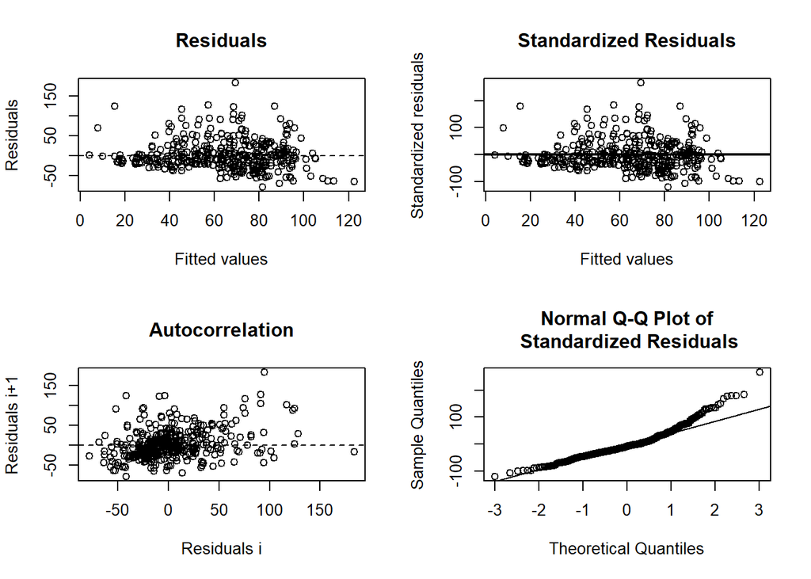

```
##
## ------
##  Shapiro-Wilk normality test
##
## data:  stdres
## W = 0.93558, p-value = 8.887e-12
##
##
## ------
```

```
##
##  Runs Test
##
## data:  as.factor(run)
## Standard Normal = -2.7515, p-value = 0.005932
## alternative hypothesis: two.sided
```

## predict and plot

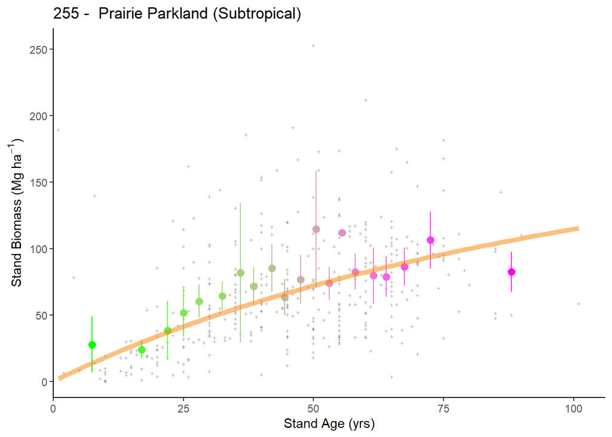

## plotting 2

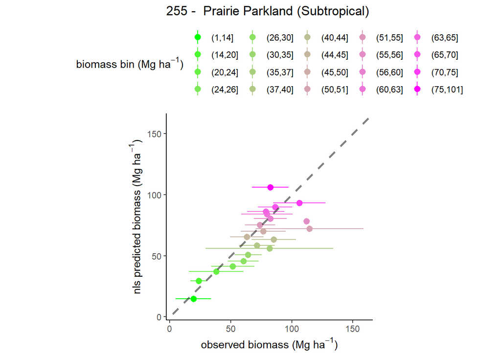

# 261 - California Coastal Chaparral Forest and Shrub

## model selection 1

```
## Error in if (any(nEQ <- vNms != make.names(vNms))) vNms[nEQ] <- paste0("`",  :
##   missing value where TRUE/FALSE needed
## Error in if (any(nEQ <- vNms != make.names(vNms))) vNms[nEQ] <- paste0("`",  :
##   missing value where TRUE/FALSE needed
## Error in if (any(nEQ <- vNms != make.names(vNms))) vNms[nEQ] <- paste0("`",  :
##   missing value where TRUE/FALSE needed
##   model AIC
## 1     1  NA
## 2     2  NA
## 3     3  NA
```

```
## Error in h(simpleError(msg, call)) :
##   error in evaluating the argument 'object' in selecting a method for function 'summary': object 'nls_261.' not found
```

### summary

- simple model: does not fit
- phi model: does not fit
- phi-alpha model: does not fit

## model selection 2

### summary

- add p model: does not fit
- add s model: does not fit
- add s+p model: does not fit
- unable to fit model (only 64 observations)

## plot residuals

```
## [1] "cannot plot residuals"
```

## predict and plot

```
## [1] "cannot plot data with prediction"
```

## plotting 2

```
## [1] "cannot plot observed vs. predicted"
```

# 262 - California Dry Steppe

## model selection 1

```
## Error in if (any(nEQ <- vNms != make.names(vNms))) vNms[nEQ] <- paste0("`",  :
##   missing value where TRUE/FALSE needed
## Error in if (any(nEQ <- vNms != make.names(vNms))) vNms[nEQ] <- paste0("`",  :
##   missing value where TRUE/FALSE needed
## Error in if (any(nEQ <- vNms != make.names(vNms))) vNms[nEQ] <- paste0("`",  :
##   missing value where TRUE/FALSE needed
##   model AIC
## 1     1  NA
## 2     2  NA
## 3     3  NA
```

```
## Error in h(simpleError(msg, call)) :
##   error in evaluating the argument 'object' in selecting a method for function 'summary': object 'nls_262.' not found
```

### summary

- simple model: does not fit
- phi model: does not fit
- phi-alpha model: does not fit

## model selection 2

### summary

- add p model: does not fit
- add s model: does not fit
- add s+p model: does not fit
- unable to fit model (0 observations)

## plot residuals

```
## [1] "cannot plot residuals"
```

## predict and plot

```
## [1] "cannot plot data with prediction"
```

## plotting 2

```
## [1] "cannot plot observed vs. predicted"
```

# 263 - California Coastal Steppe - Mixed Forest and Redwood Forest

## model selection 1

```
## Error in if (any(nEQ <- vNms != make.names(vNms))) vNms[nEQ] <- paste0("`",  :
##   missing value where TRUE/FALSE needed
## Error in if (any(nEQ <- vNms != make.names(vNms))) vNms[nEQ] <- paste0("`",  :
##   missing value where TRUE/FALSE needed
## Error in if (any(nEQ <- vNms != make.names(vNms))) vNms[nEQ] <- paste0("`",  :
##   missing value where TRUE/FALSE needed
##   model AIC
## 1     1  NA
## 2     2  NA
## 3     3  NA
```

```
## Error in h(simpleError(msg, call)) :
##   error in evaluating the argument 'object' in selecting a method for function 'summary': object 'nls_263.' not found
```

### summary

- simple model: does not fit
- phi model: does not fit
- phi-alpha model: does not fit

## model selection 2

### summary

- add p model: does not fit
- add s model: does not fit
- add s+p model: does not fit

## plot residuals

```
## [1] "cannot plot residuals"
```

## predict and plot

```
## [1] "cannot plot data with prediction"
```

## plotting 2

```
## [1] "cannot plot observed vs. predicted"
```

# 313 - Colorado Plateau Semi-Desert

## model selection 1

```
## Error in if (any(nEQ <- vNms != make.names(vNms))) vNms[nEQ] <- paste0("`",  :
##   missing value where TRUE/FALSE needed
## Error in if (any(nEQ <- vNms != make.names(vNms))) vNms[nEQ] <- paste0("`",  :
##   missing value where TRUE/FALSE needed
## Error in if (any(nEQ <- vNms != make.names(vNms))) vNms[nEQ] <- paste0("`",  :
##   missing value where TRUE/FALSE needed
##   model AIC
## 1     1  NA
## 2     2  NA
## 3     3  NA
```

```
## Error in h(simpleError(msg, call)) :
##   error in evaluating the argument 'object' in selecting a method for function 'summary': object 'nls_313.' not found
```

### summary

- simple model: does not fit
- phi model: does not fit
- phi-alpha model: does not fit

## model selection 2

### summary

- add p model: does not fit
- add s model: does not fit
- add s+p model: does not fit

## plot residuals

```
## [1] "cannot plot residuals"
```

## predict and plot

```
## [1] "cannot plot data with prediction"
```

## plotting 2

```
## [1] "cannot plot observed vs. predicted"
```

# 315 - Southwest Plateau and Plains Dry Steppe and Shrub

## model selection 1

### summary

- simple model: does not fit
- phi model: does not fit
- phi-alpha model: does not fit

## model selection 2

### summary

- add p model: does not fit
- add s model: does not fit
- add s+p model: does not fit

## plot residuals

```
## [1] "cannot plot residuals"
```

## predict and plot

```
## [1] "cannot plot data with prediction"
```

## plotting 2

```
## [1] "cannot plot observed vs. predicted"
```

# 321 - Chihuahuan Semi-Desert

## model selection 1

```
## Error in if (any(nEQ <- vNms != make.names(vNms))) vNms[nEQ] <- paste0("`",  :
##   missing value where TRUE/FALSE needed
## Error in if (any(nEQ <- vNms != make.names(vNms))) vNms[nEQ] <- paste0("`",  :
##   missing value where TRUE/FALSE needed
## Error in if (any(nEQ <- vNms != make.names(vNms))) vNms[nEQ] <- paste0("`",  :
##   missing value where TRUE/FALSE needed
##   model AIC
## 1     1  NA
## 2     2  NA
## 3     3  NA
```

```
## Error in h(simpleError(msg, call)) :
##   error in evaluating the argument 'object' in selecting a method for function 'summary': object 'nls_321.' not found
```

### summary

- simple model: does not fit
- phi model: does not fit
- phi-alpha model: does not fit

## model selection 2

### summary

- add p model: does not fit
- add s model: does not fit
- add s+p model: does not fit

## plot residuals

```
## [1] "cannot plot residuals"
```

## predict and plot

```
## [1] "cannot plot data with prediction"
```

## plotting 2

```
## [1] "cannot plot observed vs. predicted"
```

# 322 - American Semidesert and Desert

## model selection 1

[output not shown]

[output not shown]

[output not shown]

```
##   model AIC
## 1     1  NA
## 2     2  NA
## 3     3  NA
```

[output not shown]

### summary

- simple model: does not fit
- phi model: does not fit
- phi-alpha model: does not fit

## model selection 2

### summary

- add p model: does not fit
- add s model: does not fit
- add s+p model: does not fit

## plot residuals

```
## [1] "cannot plot residuals"
```

## predict and plot

```
## [1] "cannot plot data with prediction"
```

## plotting 2

```
## [1] "cannot plot observed vs. predicted"
```

- Cannot fit model
- not enough data (only 3 observations)

# 331 - Great Plains/Palouse Dry Steppe

## model selection 1

```
## Analysis of Variance Table
##
## Model 1: B_plt_t1_MgHa ~ (1 + (MEASTIME_t2 - 1990) * ge/100) * A * STDAGE_t2/(k + STDAGE_t2)
## Model 2: B_plt_t1_MgHa ~ (1 + (MEASTIME_t2 - 1990) * ge/100) * (1 + phi * DeltaPDSI) * A * STDAGE_t2/(k + STDAGE_t2)
## Model 3: B_plt_t1_MgHa ~ (1 + (MEASTIME_t2 - 1990) * ge/100) * (1 + phi * DeltaPDSI) * (1 - alpha * B_L_prop) * A * STDAGE_t2/(k + STDAGE_t2)
##   Res.Df Res.Sum Sq Df  Sum Sq F value Pr(>F)
## 1     96     47.201
## 2     95     46.279  1 0.92189  1.8924 0.1722
## 3     94     45.904  1 0.37528  0.7685 0.3829
##   model      AIC
## 1     1 1012.690
## 2     2 1012.737
## 3     3 1013.931
```

```
##
## Formula: B_plt_t1_MgHa ~ (1 + (MEASTIME_t2 - 1990) * ge/100) * A * STDAGE_t2/(k +
##     STDAGE_t2)
##
## Parameters:
##    Estimate Std. Error t value Pr(>|t|)
## ge  -0.2251     1.7525  -0.128    0.898
## A  106.2184    95.7672   1.109    0.270
## k   74.5978   111.9450   0.666    0.507
##
## Residual standard error: 0.7012 on 96 degrees of freedom
##
## Number of iterations to convergence: 18
## Achieved convergence tolerance: 7.262e-06
##   (1 observation deleted due to missingness)
```

### summary

- simple model: fits
- phi model: fits
- phi-alpha model: fits

## model selection 2

```
## Error in nls(get(paste("f_", Mod.Sel1, "a", sep = "")), data = G_331,  :
##   step factor 0.000488281 reduced below 'minFactor' of 0.000976562
## Error in nls(get(paste("f_", Mod.Sel1, "b", sep = "")), data = G_331,  :
##   step factor 0.000488281 reduced below 'minFactor' of 0.000976562
## Error in nls(get(paste("f_", Mod.Sel1, "c", sep = "")), data = G_331,  :
##   singular gradient
##   model     AIC
## 1     1 1012.69
## 2    1a      NA
## 3    1b      NA
## 4    1c      NA
```

```
##
## Formula: B_plt_t1_MgHa ~ (1 + (MEASTIME_t2 - 1990) * ge/100) * A * STDAGE_t2/(k +
##     STDAGE_t2)
##
## Parameters:
##    Estimate Std. Error t value Pr(>|t|)
## ge  -0.2251     1.7525  -0.128    0.898
## A  106.2184    95.7672   1.109    0.270
## k   74.5978   111.9450   0.666    0.507
##
## Residual standard error: 0.7012 on 96 degrees of freedom
##
## Number of iterations to convergence: 18
## Achieved convergence tolerance: 7.262e-06
##   (1 observation deleted due to missingness)
```

### summary

- add p model: does not fit
- add s model: does not fit
- add s+p model: does not fit

## plot residuals

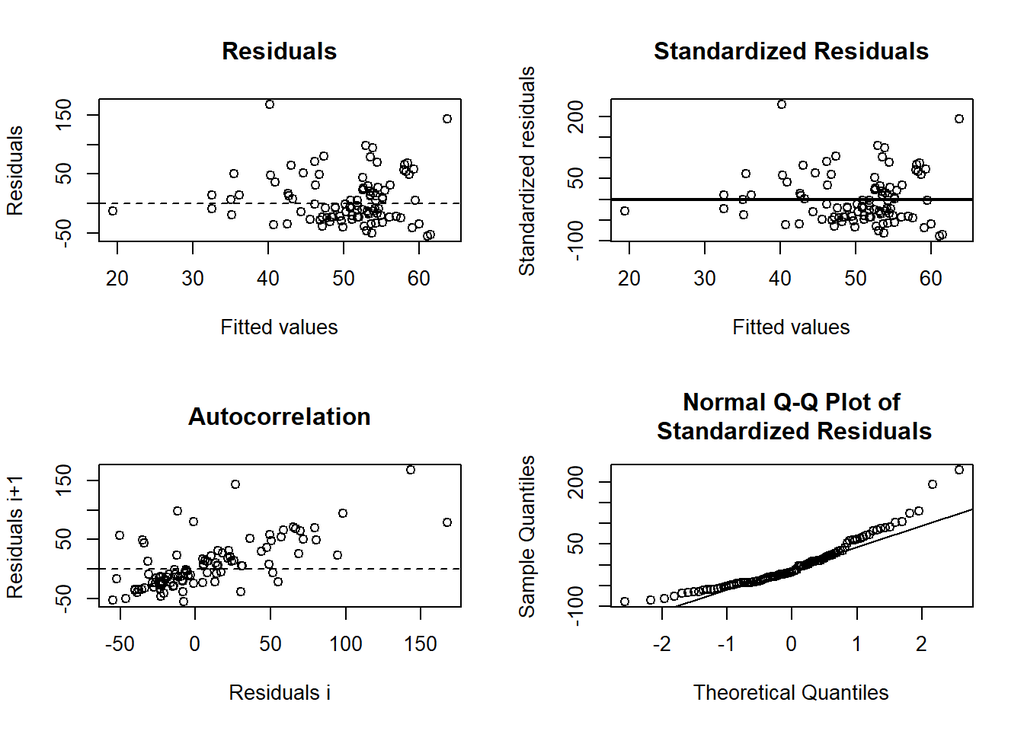

```
##
## ------
##  Shapiro-Wilk normality test
##
## data:  stdres
## W = 0.91176, p-value = 5.817e-06
##
##
## ------
```

```
##
##  Runs Test
##
## data:  as.factor(run)
## Standard Normal = -5.631, p-value = 1.791e-08
## alternative hypothesis: two.sided
```

## predict and plot

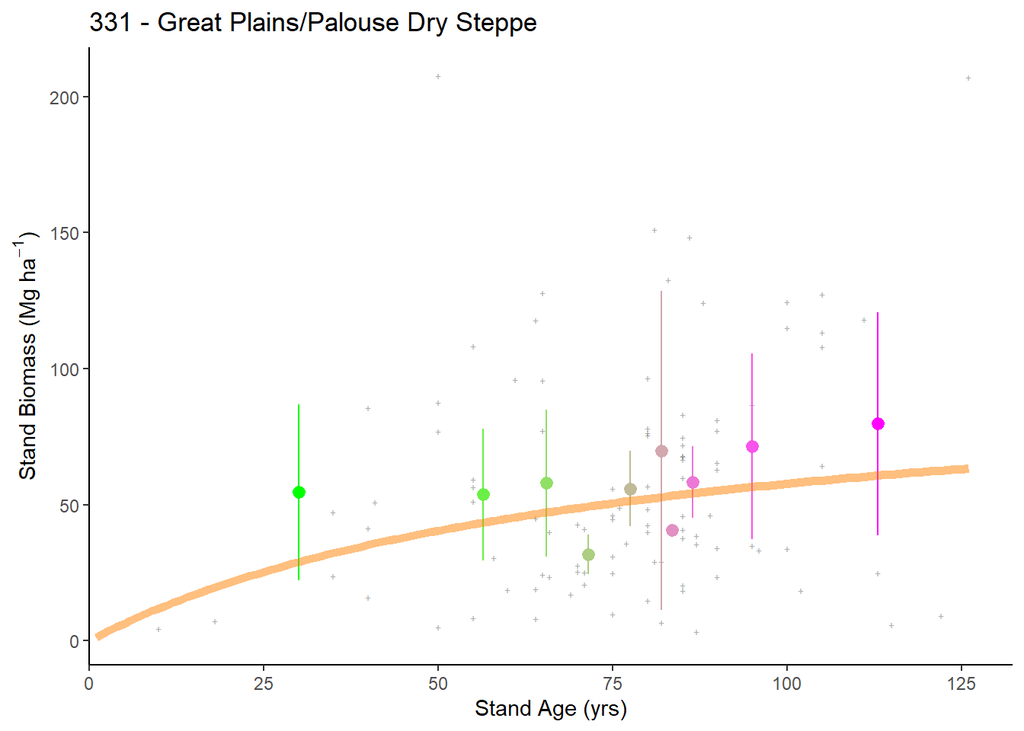

## plotting 2

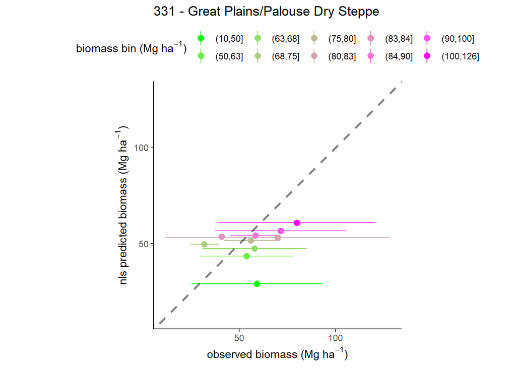

# 332 - Great Plains Steppe

## model selection 1

```
## Analysis of Variance Table
##
## Model 1: B_plt_t1_MgHa ~ (1 + (MEASTIME_t2 - 1990) * ge/100) * A * STDAGE_t2/(k + STDAGE_t2)
## Model 2: B_plt_t1_MgHa ~ (1 + (MEASTIME_t2 - 1990) * ge/100) * (1 + phi * DeltaPDSI) * A * STDAGE_t2/(k + STDAGE_t2)
## Model 3: B_plt_t1_MgHa ~ (1 + (MEASTIME_t2 - 1990) * ge/100) * (1 + phi * DeltaPDSI) * (1 - alpha * B_L_prop) * A * STDAGE_t2/(k + STDAGE_t2)
##   Res.Df Res.Sum Sq Df  Sum Sq F value Pr(>F)
## 1    120     72.590
## 2    119     72.444  1 0.14596  0.2398 0.6253
## 3    118     71.157  1 1.28724  2.1346 0.1467
##   model      AIC
## 1     1 1342.959
## 2     2 1344.711
## 3     3 1344.506
```

```
##
## Formula: B_plt_t1_MgHa ~ (1 + (MEASTIME_t2 - 1990) * ge/100) * A * STDAGE_t2/(k +
##     STDAGE_t2)
##
## Parameters:
##    Estimate Std. Error t value Pr(>|t|)
## ge    1.133      2.700   0.420    0.675
## A   388.336    692.695   0.561    0.576
## k   395.482    747.459   0.529    0.598
##
## Residual standard error: 0.7778 on 120 degrees of freedom
##
## Number of iterations to convergence: 8
## Achieved convergence tolerance: 3.378e-06
##   (1 observation deleted due to missingness)
```

### summary

- simple model: fits
- phi model: fits
- phi-alpha model: fits

## model selection 2

```
## Error in nls(get(paste("f_", Mod.Sel1, "a", sep = "")), data = G_332,  :
##   step factor 0.000488281 reduced below 'minFactor' of 0.000976562
## Error in numericDeriv(form[[3L]], names(ind), env, central = nDcentral) :
##   Missing value or an infinity produced when evaluating the model
## Error in numericDeriv(form[[3L]], names(ind), env, central = nDcentral) :
##   Missing value or an infinity produced when evaluating the model
##   model      AIC
## 1     1 1342.959
## 2    1a       NA
## 3    1b       NA
## 4    1c       NA
```

```
##
## Formula: B_plt_t1_MgHa ~ (1 + (MEASTIME_t2 - 1990) * ge/100) * A * STDAGE_t2/(k +
##     STDAGE_t2)
##
## Parameters:
##    Estimate Std. Error t value Pr(>|t|)
## ge    1.133      2.700   0.420    0.675
## A   388.336    692.695   0.561    0.576
## k   395.482    747.459   0.529    0.598
##
## Residual standard error: 0.7778 on 120 degrees of freedom
##
## Number of iterations to convergence: 8
## Achieved convergence tolerance: 3.378e-06
##   (1 observation deleted due to missingness)
```

### summary

- add p model: does not fit
- add s model: does not fit
- add s+p model: does not fit

## plot residuals

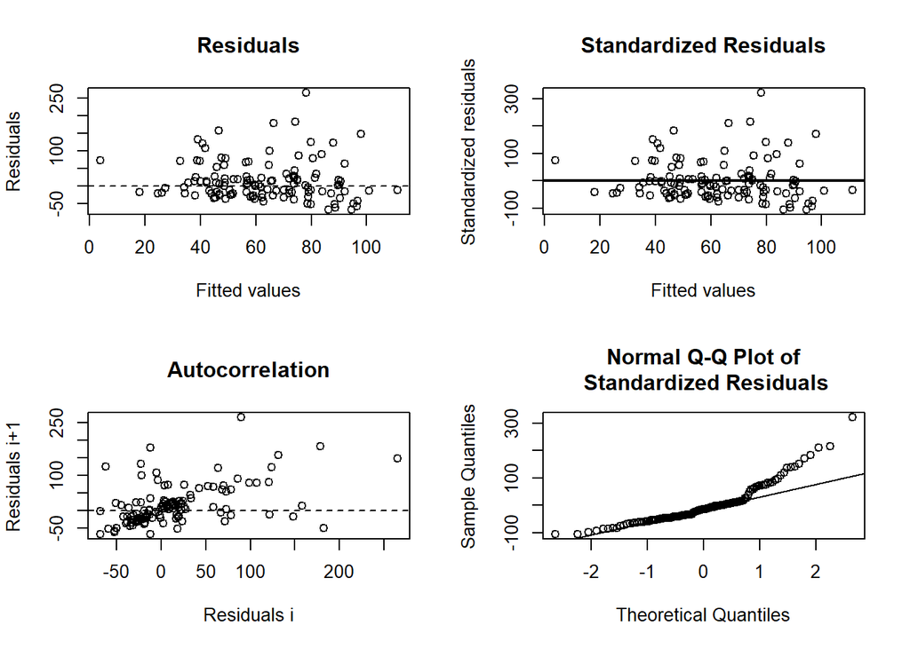

```
##
## ------
##  Shapiro-Wilk normality test
##
## data:  stdres
## W = 0.87362, p-value = 7.959e-09
##
##
## ------
```

```
##
##  Runs Test
##
## data:  as.factor(run)
## Standard Normal = -3.5973, p-value = 0.0003216
## alternative hypothesis: two.sided
```